# Project: Identify Customer Segments

In this project, you will apply unsupervised learning techniques to identify segments of the population that form the core customer base for a mail-order sales company in Germany. These segments can then be used to direct marketing campaigns towards audiences that will have the highest expected rate of returns. The data that you will use has been provided by our partners at Bertelsmann Arvato Analytics, and represents a real-life data science task.

This notebook will help you complete this task by providing a framework within which you will perform your analysis steps. In each step of the project, you will see some text describing the subtask that you will perform, followed by one or more code cells for you to complete your work. **Feel free to add additional code and markdown cells as you go along so that you can explore everything in precise chunks.** The code cells provided in the base template will outline only the major tasks, and will usually not be enough to cover all of the minor tasks that comprise it.

It should be noted that while there will be precise guidelines on how you should handle certain tasks in the project, there will also be places where an exact specification is not provided. **There will be times in the project where you will need to make and justify your own decisions on how to treat the data.** These are places where there may not be only one way to handle the data. In real-life tasks, there may be many valid ways to approach an analysis task. One of the most important things you can do is clearly document your approach so that other scientists can understand the decisions you've made.

At the end of most sections, there will be a Markdown cell labeled **Discussion**. In these cells, you will report your findings for the completed section, as well as document the decisions that you made in your approach to each subtask. **Your project will be evaluated not just on the code used to complete the tasks outlined, but also your communication about your observations and conclusions at each stage.**

```python
# import libraries here; add more as necessary
import numpy as np
import pandas as pd
import matplotlib.pyplot as plt
import seaborn as sns

import re
import time

from sklearn.preprocessing import Imputer, StandardScaler
from sklearn.decomposition import PCA
from sklearn.cluster import KMeans

# magic word for producing visualizations in notebook
%matplotlib inline
%config InlineBackend.figure_format = 'retina'
```

### Step 0: Load the Data

There are four files associated with this project (not including this one):

Each row of the demographics files represents a single person, but also includes information outside of individuals, including information about their household, building, and neighborhood. You will use this information to cluster the general population into groups with similar demographic properties. Then, you will see how the people in the customers dataset fit into those created clusters. The hope here is that certain clusters are over-represented in the customers data, as compared to the general population; those over-represented clusters will be assumed to be part of the core userbase. This information can then be used for further applications, such as targeting for a marketing campaign.

To start off with, load in the demographics data for the general population into a pandas DataFrame, and do the same for the feature attributes summary. Note for all of the `.csv` data files in this project: they're semicolon (`;`) delimited, so you'll need an additional argument in your [`read_csv()`](https://pandas.pydata.org/pandas-docs/stable/generated/pandas.read_csv.html) call to read in the data properly. Also, considering the size of the main dataset, it may take some time for it to load completely.

Once the dataset is loaded, it's recommended that you take a little bit of time just browsing the general structure of the dataset and feature summary file. You'll be getting deep into the innards of the cleaning in the first major step of the project, so gaining some general familiarity can help you get your bearings.

```python
# Load in the general demographics data.
azdias = pd.read_csv("./data/Udacity_AZDIAS_Subset.csv", sep=";")

# Load in the feature summary file.
feat_info = pd.read_csv("./data/AZDIAS_Feature_Summary.csv", sep=";")
```

First exploring the general demographics data.

```python
azdias.head(20)
```

|  | AGER_TYP | ALTERSKATEGORIE_GROB | ANREDE_KZ | CJT_GESAMTTYP | FINANZ_MINIMALIST | FINANZ_SPARER | FINANZ_VORSORGER | FINANZ_ANLEGER | FINANZ_UNAUFFAELLIGER | FINANZ_HAUSBAUER | ... | PLZ8_ANTG1 | PLZ8_ANTG2 | PLZ8_ANTG3 | PLZ8_ANTG4 | PLZ8_BAUMAX | PLZ8_HHZ | PLZ8_GBZ | ARBEIT | ORTSGR_KLS9 | RELAT_AB |
| --- | --- | --- | --- | --- | --- | --- | --- | --- | --- | --- | --- | --- | --- | --- | --- | --- | --- | --- | --- | --- | --- |
| 0 | -1 | 2 | 1 | 2.0 | 3 | 4 | 3 | 5 | 5 | 3 | ... | NaN | NaN | NaN | NaN | NaN | NaN | NaN | NaN | NaN | NaN |
| 1 | -1 | 1 | 2 | 5.0 | 1 | 5 | 2 | 5 | 4 | 5 | ... | 2.0 | 3.0 | 2.0 | 1.0 | 1.0 | 5.0 | 4.0 | 3.0 | 5.0 | 4.0 |
| 2 | -1 | 3 | 2 | 3.0 | 1 | 4 | 1 | 2 | 3 | 5 | ... | 3.0 | 3.0 | 1.0 | 0.0 | 1.0 | 4.0 | 4.0 | 3.0 | 5.0 | 2.0 |
| 3 | 2 | 4 | 2 | 2.0 | 4 | 2 | 5 | 2 | 1 | 2 | ... | 2.0 | 2.0 | 2.0 | 0.0 | 1.0 | 3.0 | 4.0 | 2.0 | 3.0 | 3.0 |
| 4 | -1 | 3 | 1 | 5.0 | 4 | 3 | 4 | 1 | 3 | 2 | ... | 2.0 | 4.0 | 2.0 | 1.0 | 2.0 | 3.0 | 3.0 | 4.0 | 6.0 | 5.0 |
| 5 | 3 | 1 | 2 | 2.0 | 3 | 1 | 5 | 2 | 2 | 5 | ... | 2.0 | 3.0 | 1.0 | 1.0 | 1.0 | 5.0 | 5.0 | 2.0 | 3.0 | 3.0 |
| 6 | -1 | 2 | 2 | 5.0 | 1 | 5 | 1 | 5 | 4 | 3 | ... | 3.0 | 3.0 | 1.0 | 0.0 | 1.0 | 5.0 | 5.0 | 4.0 | 6.0 | 3.0 |
| 7 | -1 | 1 | 1 | 3.0 | 3 | 3 | 4 | 1 | 3 | 2 | ... | 3.0 | 3.0 | 1.0 | 0.0 | 1.0 | 4.0 | 4.0 | 2.0 | 5.0 | 2.0 |
| 8 | -1 | 3 | 1 | 3.0 | 4 | 4 | 2 | 4 | 2 | 2 | ... | 2.0 | 3.0 | 2.0 | 1.0 | 1.0 | 3.0 | 3.0 | 2.0 | 4.0 | 3.0 |
| 9 | -1 | 3 | 2 | 4.0 | 2 | 4 | 2 | 3 | 5 | 4 | ... | 2.0 | 3.0 | 2.0 | 1.0 | 1.0 | 3.0 | 3.0 | 2.0 | 3.0 | 1.0 |
| 10 | 0 | 3 | 2 | 1.0 | 2 | 2 | 5 | 3 | 1 | 5 | ... | 2.0 | 4.0 | 2.0 | 0.0 | 2.0 | 3.0 | 3.0 | 4.0 | 6.0 | 5.0 |
| 11 | -1 | 2 | 1 | 6.0 | 3 | 4 | 3 | 5 | 5 | 3 | ... | NaN | NaN | NaN | NaN | NaN | NaN | NaN | NaN | NaN | NaN |
| 12 | -1 | 3 | 1 | 6.0 | 5 | 3 | 4 | 2 | 4 | 1 | ... | 3.0 | 3.0 | 1.0 | 0.0 | 1.0 | 5.0 | 5.0 | 3.0 | 6.0 | 4.0 |
| 13 | -1 | 1 | 2 | 5.0 | 1 | 4 | 3 | 5 | 5 | 2 | ... | 2.0 | 1.0 | 1.0 | 1.0 | 1.0 | 3.0 | 3.0 | 3.0 | 6.0 | 4.0 |
| 14 | -1 | 3 | 1 | 6.0 | 3 | 4 | 3 | 5 | 5 | 3 | ... | NaN | NaN | NaN | NaN | NaN | NaN | NaN | NaN | NaN | NaN |
| 15 | 1 | 4 | 2 | 4.0 | 4 | 1 | 5 | 1 | 1 | 4 | ... | NaN | NaN | NaN | NaN | NaN | NaN | NaN | 4.0 | 8.0 | 5.0 |
| 16 | -1 | 1 | 2 | 1.0 | 4 | 3 | 1 | 4 | 5 | 1 | ... | 3.0 | 3.0 | 1.0 | 0.0 | 1.0 | 3.0 | 4.0 | 1.0 | 2.0 | 1.0 |
| 17 | -1 | 2 | 1 | 6.0 | 3 | 4 | 3 | 5 | 5 | 3 | ... | NaN | NaN | NaN | NaN | NaN | NaN | NaN | NaN | NaN | NaN |
| 18 | -1 | 2 | 2 | 6.0 | 2 | 4 | 1 | 5 | 4 | 1 | ... | 2.0 | 3.0 | 2.0 | 1.0 | 1.0 | 3.0 | 3.0 | 3.0 | 4.0 | 3.0 |
| 19 | -1 | 3 | 1 | 3.0 | 5 | 2 | 3 | 1 | 3 | 1 | ... | 2.0 | 4.0 | 2.0 | 1.0 | 2.0 | 5.0 | 4.0 | 4.0 | 6.0 | 3.0 |

20 rows × 85 columns

```python
azdias.shape
```

```
(891221, 85)
```

```python
azdias.index
```

```
RangeIndex(start=0, stop=891221, step=1)
```

```python
azdias.columns
```

```
Index(['AGER_TYP', 'ALTERSKATEGORIE_GROB', 'ANREDE_KZ', 'CJT_GESAMTTYP',
       'FINANZ_MINIMALIST', 'FINANZ_SPARER', 'FINANZ_VORSORGER',
       'FINANZ_ANLEGER', 'FINANZ_UNAUFFAELLIGER', 'FINANZ_HAUSBAUER',
       'FINANZTYP', 'GEBURTSJAHR', 'GFK_URLAUBERTYP', 'GREEN_AVANTGARDE',
       'HEALTH_TYP', 'LP_LEBENSPHASE_FEIN', 'LP_LEBENSPHASE_GROB',
       'LP_FAMILIE_FEIN', 'LP_FAMILIE_GROB', 'LP_STATUS_FEIN',
       'LP_STATUS_GROB', 'NATIONALITAET_KZ', 'PRAEGENDE_JUGENDJAHRE',
       'RETOURTYP_BK_S', 'SEMIO_SOZ', 'SEMIO_FAM', 'SEMIO_REL', 'SEMIO_MAT',
       'SEMIO_VERT', 'SEMIO_LUST', 'SEMIO_ERL', 'SEMIO_KULT', 'SEMIO_RAT',
       'SEMIO_KRIT', 'SEMIO_DOM', 'SEMIO_KAEM', 'SEMIO_PFLICHT', 'SEMIO_TRADV',
       'SHOPPER_TYP', 'SOHO_KZ', 'TITEL_KZ', 'VERS_TYP', 'ZABEOTYP',
       'ALTER_HH', 'ANZ_PERSONEN', 'ANZ_TITEL', 'HH_EINKOMMEN_SCORE',
       'KK_KUNDENTYP', 'W_KEIT_KIND_HH', 'WOHNDAUER_2008',
       'ANZ_HAUSHALTE_AKTIV', 'ANZ_HH_TITEL', 'GEBAEUDETYP', 'KONSUMNAEHE',
       'MIN_GEBAEUDEJAHR', 'OST_WEST_KZ', 'WOHNLAGE', 'CAMEO_DEUG_2015',
       'CAMEO_DEU_2015', 'CAMEO_INTL_2015', 'KBA05_ANTG1', 'KBA05_ANTG2',
       'KBA05_ANTG3', 'KBA05_ANTG4', 'KBA05_BAUMAX', 'KBA05_GBZ', 'BALLRAUM',
       'EWDICHTE', 'INNENSTADT', 'GEBAEUDETYP_RASTER', 'KKK', 'MOBI_REGIO',
       'ONLINE_AFFINITAET', 'REGIOTYP', 'KBA13_ANZAHL_PKW', 'PLZ8_ANTG1',
       'PLZ8_ANTG2', 'PLZ8_ANTG3', 'PLZ8_ANTG4', 'PLZ8_BAUMAX', 'PLZ8_HHZ',
       'PLZ8_GBZ', 'ARBEIT', 'ORTSGR_KLS9', 'RELAT_AB'],
      dtype='object')
```

Next explore the feature summary

```python
feat_info.head(20)
```

|  | attribute | information_level | type | missing_or_unknown |
| --- | --- | --- | --- | --- |
| 0 | AGER_TYP | person | categorical | [-1,0] |
| 1 | ALTERSKATEGORIE_GROB | person | ordinal | [-1,0,9] |
| 2 | ANREDE_KZ | person | categorical | [-1,0] |
| 3 | CJT_GESAMTTYP | person | categorical | [0] |
| 4 | FINANZ_MINIMALIST | person | ordinal | [-1] |
| 5 | FINANZ_SPARER | person | ordinal | [-1] |
| 6 | FINANZ_VORSORGER | person | ordinal | [-1] |
| 7 | FINANZ_ANLEGER | person | ordinal | [-1] |
| 8 | FINANZ_UNAUFFAELLIGER | person | ordinal | [-1] |
| 9 | FINANZ_HAUSBAUER | person | ordinal | [-1] |
| 10 | FINANZTYP | person | categorical | [-1] |
| 11 | GEBURTSJAHR | person | numeric | [0] |
| 12 | GFK_URLAUBERTYP | person | categorical | [] |
| 13 | GREEN_AVANTGARDE | person | categorical | [] |
| 14 | HEALTH_TYP | person | ordinal | [-1,0] |
| 15 | LP_LEBENSPHASE_FEIN | person | mixed | [0] |
| 16 | LP_LEBENSPHASE_GROB | person | mixed | [0] |
| 17 | LP_FAMILIE_FEIN | person | categorical | [0] |
| 18 | LP_FAMILIE_GROB | person | categorical | [0] |
| 19 | LP_STATUS_FEIN | person | categorical | [0] |

```python
feat_info.shape
```

```
(85, 4)
```

```python
feat_info.index
```

```
RangeIndex(start=0, stop=85, step=1)
```

```python
feat_info.columns
```

```
Index(['attribute', 'information_level', 'type', 'missing_or_unknown'], dtype='object')
```

> **Tip**: Add additional cells to keep everything in reasonably-sized chunks! Keyboard shortcut `esc --> a` (press escape to enter command mode, then press the 'A' key) adds a new cell before the active cell, and `esc --> b` adds a new cell after the active cell. If you need to convert an active cell to a markdown cell, use `esc --> m` and to convert to a code cell, use `esc --> y`.

## Step 1: Preprocessing

### Step 1.1: Assess Missing Data

The feature summary file contains a summary of properties for each demographics data column. You will use this file to help you make cleaning decisions during this stage of the project. First of all, you should assess the demographics data in terms of missing data. Pay attention to the following points as you perform your analysis, and take notes on what you observe. Make sure that you fill in the **Discussion** cell with your findings and decisions at the end of each step that has one!

#### Step 1.1.1: Convert Missing Value Codes to NaNs

The fourth column of the feature attributes summary (loaded in above as `feat_info`) documents the codes from the data dictionary that indicate missing or unknown data. While the file encodes this as a list (e.g. `[-1,0]`), this will get read in as a string object. You'll need to do a little bit of parsing to make use of it to identify and clean the data. Convert data that matches a 'missing' or 'unknown' value code into a numpy NaN value. You might want to see how much data takes on a 'missing' or 'unknown' code, and how much data is naturally missing, as a point of interest.

**As one more reminder, you are encouraged to add additional cells to break up your analysis into manageable chunks.**

```python
# Identify missing or unknown data values and convert them to NaNs.

# Function to convert a string representing a list into an actual list of values.
def str_to_list(s):
    l = []
    for ss in s.replace("[", "").replace("]", "").split(","):
        if re.match("^\-?\d+$", ss):
            ss = int(ss)
        l.append(ss)
    return l
```

```python
feat_info["missing_or_unknown_converted"] = feat_info["missing_or_unknown"]
for i, s in enumerate(feat_info["missing_or_unknown_converted"]):
    feat_info["missing_or_unknown_converted"][i] = str_to_list(s)

print(f"Before: {feat_info['missing_or_unknown'][0]} \n"
      f"After:  {feat_info['missing_or_unknown_converted'][0]}")
```

```
Before: [-1,0]
After:  [-1, 0]
```

```python
# Replace missing or unknown values with np NaN.
azdias[['AGER_TYP', 'TITEL_KZ']].head(25)
```

|  | AGER_TYP | TITEL_KZ |
| --- | --- | --- |
| 0 | -1 | NaN |
| 1 | -1 | 0.0 |
| 2 | -1 | 0.0 |
| 3 | 2 | 0.0 |
| 4 | -1 | 0.0 |
| 5 | 3 | 0.0 |
| 6 | -1 | 0.0 |
| 7 | -1 | 0.0 |
| 8 | -1 | 0.0 |
| 9 | -1 | 0.0 |
| 10 | 0 | 0.0 |
| 11 | -1 | NaN |
| 12 | -1 | 0.0 |
| 13 | -1 | 0.0 |
| 14 | -1 | NaN |
| 15 | 1 | 0.0 |
| 16 | -1 | 0.0 |
| 17 | -1 | NaN |
| 18 | -1 | 0.0 |
| 19 | -1 | 0.0 |
| 20 | -1 | 0.0 |
| 21 | -1 | 0.0 |
| 22 | -1 | 0.0 |
| 23 | -1 | 0.0 |
| 24 | -1 | NaN |

```python
for i, c in enumerate(azdias.columns):
    azdias[c] = azdias[c].replace(feat_info["missing_or_unknown_converted"][i], np.nan)
```

```python
# After
azdias[['AGER_TYP', 'TITEL_KZ']].head(25)
```

|  | AGER_TYP | TITEL_KZ |
| --- | --- | --- |
| 0 | NaN | NaN |
| 1 | NaN | NaN |
| 2 | NaN | NaN |
| 3 | 2.0 | NaN |
| 4 | NaN | NaN |
| 5 | 3.0 | NaN |
| 6 | NaN | NaN |
| 7 | NaN | NaN |
| 8 | NaN | NaN |
| 9 | NaN | NaN |
| 10 | NaN | NaN |
| 11 | NaN | NaN |
| 12 | NaN | NaN |
| 13 | NaN | NaN |
| 14 | NaN | NaN |
| 15 | 1.0 | NaN |
| 16 | NaN | NaN |
| 17 | NaN | NaN |
| 18 | NaN | NaN |
| 19 | NaN | NaN |
| 20 | NaN | NaN |
| 21 | NaN | NaN |
| 22 | NaN | NaN |
| 23 | NaN | NaN |
| 24 | NaN | NaN |

#### Step 1.1.2: Assess Missing Data in Each Column

How much missing data is present in each column? There are a few columns that are outliers in terms of the proportion of values that are missing. You will want to use matplotlib's [`hist()`](https://matplotlib.org/api/_as_gen/matplotlib.pyplot.hist.html) function to visualize the distribution of missing value counts to find these columns. Identify and document these columns. While some of these columns might have justifications for keeping or re-encoding the data, for this project you should just remove them from the dataframe. (Feel free to make remarks about these outlier columns in the discussion, however!)

For the remaining features, are there any patterns in which columns have, or share, missing data?

```python
# Perform an assessment of how much missing data there is in each column of the
# dataset.

# Missing data per column?
missing_data = azdias.isnull().sum()
missing_columns = missing_data[missing_data != 0]
missing_columns.sort_values(ascending=False)
```

```
TITEL_KZ                 889061
AGER_TYP                 685843
KK_KUNDENTYP             584612
KBA05_BAUMAX             476524
GEBURTSJAHR              392318
ALTER_HH                 310267
REGIOTYP                 158064
KKK                      158064
W_KEIT_KIND_HH           147988
KBA05_ANTG4              133324
KBA05_GBZ                133324
MOBI_REGIO               133324
KBA05_ANTG1              133324
KBA05_ANTG2              133324
KBA05_ANTG3              133324
PLZ8_GBZ                 116515
PLZ8_HHZ                 116515
PLZ8_BAUMAX              116515
PLZ8_ANTG4               116515
PLZ8_ANTG1               116515
PLZ8_ANTG3               116515
PLZ8_ANTG2               116515
SHOPPER_TYP              111196
VERS_TYP                 111196
HEALTH_TYP               111196
NATIONALITAET_KZ         108315
PRAEGENDE_JUGENDJAHRE    108164
KBA13_ANZAHL_PKW         105800
ANZ_HAUSHALTE_AKTIV       99611
CAMEO_INTL_2015           99352
                          ...
CAMEO_DEUG_2015           99352
LP_LEBENSPHASE_FEIN       97632
RELAT_AB                  97375
ARBEIT                    97375
ORTSGR_KLS9               97274
ANZ_HH_TITEL              97008
LP_LEBENSPHASE_GROB       94572
INNENSTADT                93740
BALLRAUM                  93740
EWDICHTE                  93740
GEBAEUDETYP_RASTER        93155
MIN_GEBAEUDEJAHR          93148
OST_WEST_KZ               93148
WOHNLAGE                  93148
GEBAEUDETYP               93148
LP_FAMILIE_FEIN           77792
LP_FAMILIE_GROB           77792
KONSUMNAEHE               73969
WOHNDAUER_2008            73499
ANZ_TITEL                 73499
SOHO_KZ                   73499
ANZ_PERSONEN              73499
HH_EINKOMMEN_SCORE        18348
LP_STATUS_GROB             4854
LP_STATUS_FEIN             4854
RETOURTYP_BK_S             4854
ONLINE_AFFINITAET          4854
GFK_URLAUBERTYP            4854
CJT_GESAMTTYP              4854
ALTERSKATEGORIE_GROB       2881
Length: 61, dtype: int64
```

```python
missing_columns.describe()
```

```
count        61.000000
mean     137277.524590
std      157099.496443
min        2881.000000
25%       93148.000000
50%       99352.000000
75%      116515.000000
max      889061.000000
dtype: float64
```

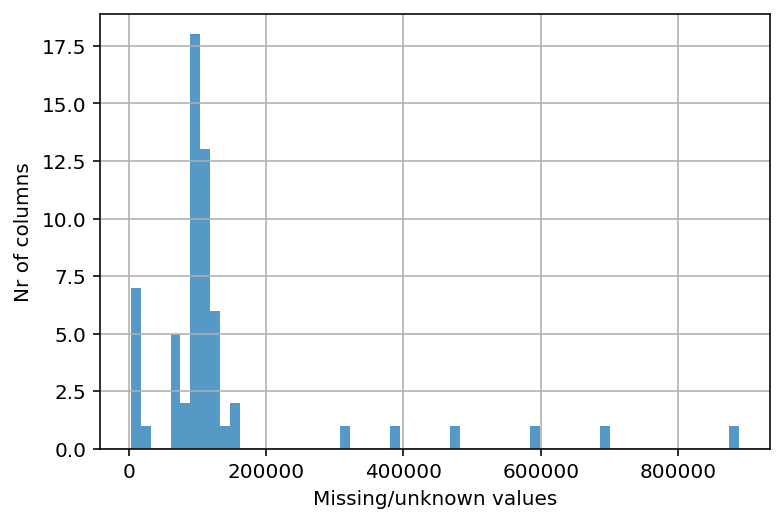

```python
plt.hist(missing_columns, len(missing_columns), alpha=0.75)
plt.xlabel('Missing/unknown values')
plt.ylabel('Nr of columns')
plt.grid(True)
plt.show()
```

```python
missing_column_names = missing_columns[missing_columns > 300000].index.values
missing_column_names
```

```
array(['AGER_TYP', 'GEBURTSJAHR', 'TITEL_KZ', 'ALTER_HH', 'KK_KUNDENTYP',
       'KBA05_BAUMAX'], dtype=object)
```

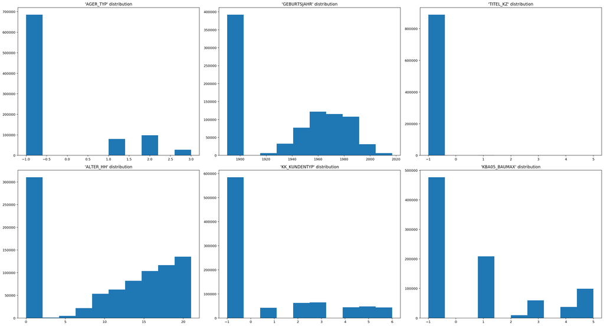

```python
ncols = 3
nrows = int(len(missing_column_names)/ncols)+1

map_missing = {
    'AGER_TYP': -1,
    'GEBURTSJAHR': 1890,
    'TITEL_KZ': -1,
    'KK_KUNDENTYP': -1,
    'KBA05_BAUMAX': -1,
    'ALTER_HH': 0
}

fig = plt.figure(figsize=(25,20))
for i, c in enumerate(missing_column_names):
    ax = fig.add_subplot(nrows, ncols, i + 1 % 2)
    ax.set_title(f"'{c}' distribution")
    ax.hist(azdias[c].fillna(map_missing[c]))
fig.tight_layout()
fig.show()
```

```python
# Remove the outlier columns from the dataset. (You'll perform other data
# engineering tasks such as re-encoding and imputation later.)

azdias.drop(missing_column_names, axis=1, inplace=True)
```

```python
feat_info_dropped = feat_info[~feat_info['attribute'].isin(missing_column_names)]
```

#### Discussion 1.1.2: Assess Missing Data in Each Column

Based on analysis of the variables `missing_unknown_data` (which contains the number of missing or unknown datapoints for each columns) `missing_unknown_columns` (similar to `missing_unknown_data` but only contains the columns with missing or unknown datapoint), we know that 24 columns have no missing data. Thus 61 columns have 1 or more missing or unknown data points.

These outliers are `AGER_TYP`, `GEBURTSJAHR`, `TITEL_KZ`, `ALTER_HH`, `KK_KUNDENTYP` and `KBA05_BAUMAX`.

#### Step 1.1.3: Assess Missing Data in Each Row

Now, you'll perform a similar assessment for the rows of the dataset. How much data is missing in each row? As with the columns, you should see some groups of points that have a very different numbers of missing values. Divide the data into two subsets: one for data points that are above some threshold for missing values, and a second subset for points below that threshold.

In order to know what to do with the outlier rows, we should see if the distribution of data values on columns that are not missing data (or are missing very little data) are similar or different between the two groups. Select at least five of these columns and compare the distribution of values.

- You can use seaborn's [`countplot()`](https://seaborn.pydata.org/generated/seaborn.countplot.html) function to create a bar chart of code frequencies and matplotlib's [`subplot()`](https://matplotlib.org/api/_as_gen/matplotlib.pyplot.subplot.html) function to put bar charts for the two subplots side by side.
- To reduce repeated code, you might want to write a function that can perform this comparison, taking as one of its arguments a column to be compared.

Depending on what you observe in your comparison, this will have implications on how you approach your conclusions later in the analysis. If the distributions of non-missing features look similar between the data with many missing values and the data with few or no missing values, then we could argue that simply dropping those points from the analysis won't present a major issue. On the other hand, if the data with many missing values looks very different from the data with few or no missing values, then we should make a note on those data as special. We'll revisit these data later on. **Either way, you should continue your analysis for now using just the subset of the data with few or no missing values.**

```python
# How much data is missing in each row of the dataset?
missing_rows = azdias.isnull().sum(axis=1)
missing_rows
```

```
0         43
1          0
2          0
3          7
4          0
5          0
6          0
7          0
8          0
9          0
10         0
11        47
12         6
13         8
14        47
```

[output cut: 47 more lines]

```python
missing_rows.describe()
```

```
count    891221.000000
mean          5.649894
std          13.234687
min           0.000000
25%           0.000000
50%           0.000000
75%           3.000000
max          49.000000
dtype: float64
```

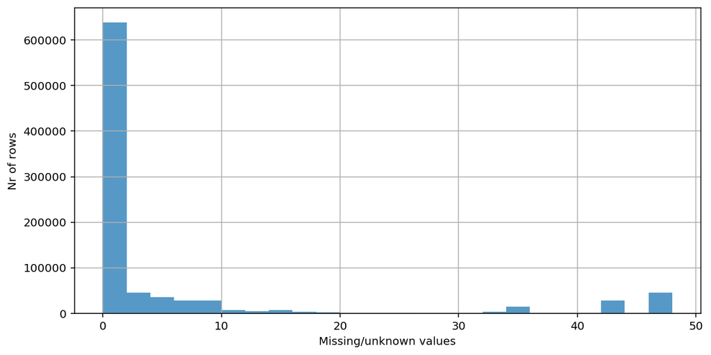

```python
plt.figure(figsize=(10, 5))
plt.hist(missing_rows, bins=np.arange(0, 50, 2), alpha=0.75)
plt.xlabel('Missing/unknown values')
plt.ylabel('Nr of rows')
plt.grid(True)
plt.show()
```

An analysis of the amount of data missing for each row shows that a very large majority of rows has less than 20 datapoints missing. There are a smaller amount of rows that are missing 30 or more feature values. We'll use 25 as threshold to divide the rows.

```python
# Write code to divide the data into two subsets based on the number of missing
# values in each row.

missing_rows_many = missing_rows[missing_rows > 25]
missing_rows_few = missing_rows[missing_rows <= 25]
print(f"{missing_rows_many.shape[0]} rows out of {azdias.shape[0]} have 25 or more missing columns values.")
```

```
93260 rows out of 891221 have 25 or more missing columns values.
```

```python
# Compare the distribution of values for at least five columns where there are
# no or few missing values, between the two subsets.
```

We'll compare following 5 columns for further analysis

| feature | meaning | missing values |
| --- | --- | --- |
| LP_STATUS_FEIN | Social status, fine scale | 4854 |
| ONLINE_AFFINITAET | Online affinity | 4854 |
| GFK_URLAUBERTYP | Vacation habits | 4854 |
| CJT_GESAMTTYP | Customer-Journey-Typology | 4854 |
| ALTERSKATEGORIE_GROB | Estimated age | 2881 |

```python
def columns_compare_missing_rows(column):
    fig = plt.figure(figsize=(10, 4))
    ax = fig.add_subplot(1, 2, 1)
    ax.title.set_text('Few missing rows')
    sns.countplot(azdias.loc[missing_rows_few.index, column])

    ax = fig.add_subplot(1, 2, 2)
    ax.title.set_text('Many missing rows')
    sns.countplot(azdias.loc[missing_rows_many.index, column])

    fig.suptitle(column)
    plt.show()
```

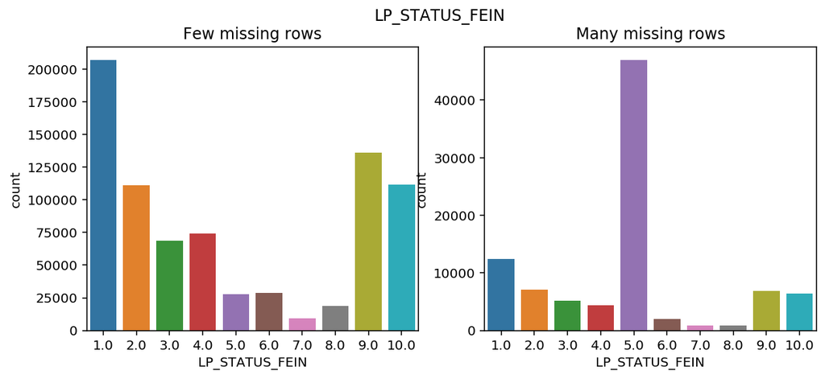

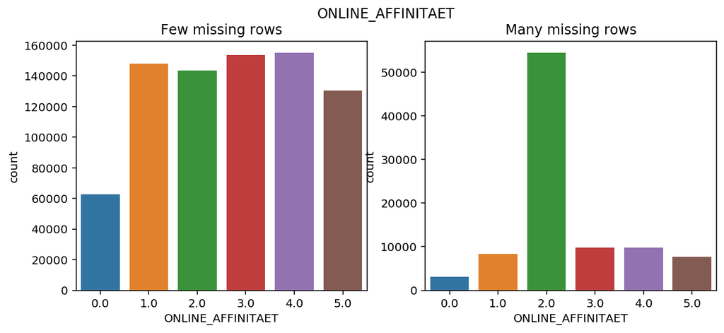

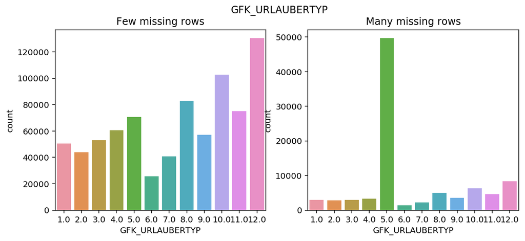

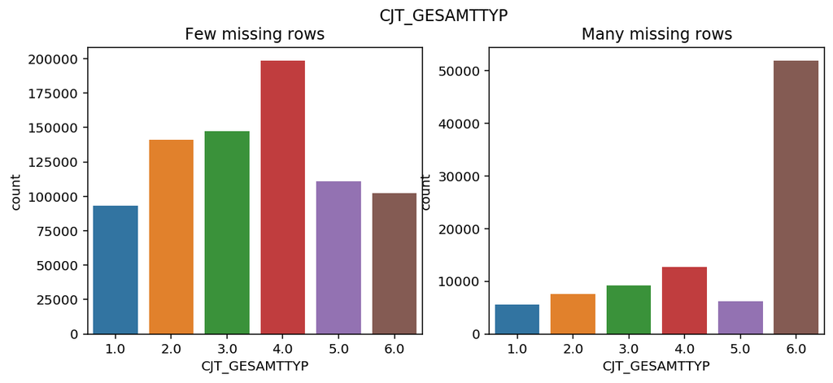

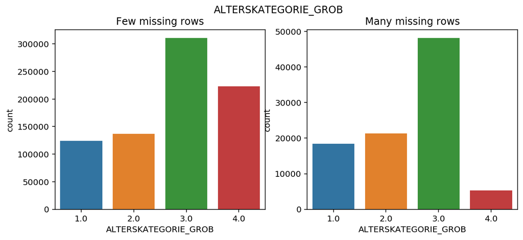

```python
columns_min_missing_values = [
    'LP_STATUS_FEIN',
    'ONLINE_AFFINITAET',
    'GFK_URLAUBERTYP',
    'CJT_GESAMTTYP',
    'ALTERSKATEGORIE_GROB'
]

for c in columns_min_missing_values:
    columns_compare_missing_rows(c)
```

```python
# Store rows with many missing values for later.
azdias_many_missing_rows = azdias.iloc[missing_rows_many.index]
azdias_many_missing_rows.describe()
```

|  | ALTERSKATEGORIE_GROB | ANREDE_KZ | CJT_GESAMTTYP | FINANZ_MINIMALIST | FINANZ_SPARER | FINANZ_VORSORGER | FINANZ_ANLEGER | FINANZ_UNAUFFAELLIGER | FINANZ_HAUSBAUER | FINANZTYP | ... | PLZ8_ANTG1 | PLZ8_ANTG2 | PLZ8_ANTG3 | PLZ8_ANTG4 | PLZ8_BAUMAX | PLZ8_HHZ | PLZ8_GBZ | ARBEIT | ORTSGR_KLS9 | RELAT_AB |
| --- | --- | --- | --- | --- | --- | --- | --- | --- | --- | --- | --- | --- | --- | --- | --- | --- | --- | --- | --- | --- | --- |
| count | 93180.000000 | 93260.000000 | 93119.000000 | 93260.000000 | 93260.000000 | 93260.000000 | 93260.000000 | 93260.000000 | 93260.000000 | 93260.000000 | ... | 0.0 | 0.0 | 0.0 | 0.0 | 0.0 | 0.0 | 0.0 | 112.000000 | 112.000000 | 112.000000 |
| mean | 2.431348 | 1.527429 | 4.740493 | 3.208160 | 3.719966 | 3.128941 | 4.679991 | 4.722325 | 2.740157 | 3.727536 | ... | NaN | NaN | NaN | NaN | NaN | NaN | NaN | 2.857143 | 4.723214 | 2.758929 |
| std | 0.868782 | 0.499250 | 1.645027 | 0.648448 | 0.854347 | 0.633056 | 0.878499 | 0.741959 | 0.640915 | 0.757090 | ... | NaN | NaN | NaN | NaN | NaN | NaN | NaN | 1.047151 | 2.461267 | 1.323696 |
| min | 1.000000 | 1.000000 | 1.000000 | 1.000000 | 1.000000 | 1.000000 | 1.000000 | 1.000000 | 1.000000 | 1.000000 | ... | NaN | NaN | NaN | NaN | NaN | NaN | NaN | 1.000000 | 1.000000 | 1.000000 |
| 25% | 2.000000 | 1.000000 | 4.000000 | 3.000000 | 4.000000 | 3.000000 | 5.000000 | 5.000000 | 3.000000 | 4.000000 | ... | NaN | NaN | NaN | NaN | NaN | NaN | NaN | 2.000000 | 3.000000 | 1.750000 |
| 50% | 3.000000 | 2.000000 | 6.000000 | 3.000000 | 4.000000 | 3.000000 | 5.000000 | 5.000000 | 3.000000 | 4.000000 | ... | NaN | NaN | NaN | NaN | NaN | NaN | NaN | 3.000000 | 5.000000 | 3.000000 |
| 75% | 3.000000 | 2.000000 | 6.000000 | 3.000000 | 4.000000 | 3.000000 | 5.000000 | 5.000000 | 3.000000 | 4.000000 | ... | NaN | NaN | NaN | NaN | NaN | NaN | NaN | 4.000000 | 6.000000 | 4.000000 |
| max | 4.000000 | 2.000000 | 6.000000 | 5.000000 | 5.000000 | 5.000000 | 5.000000 | 5.000000 | 5.000000 | 6.000000 | ... | NaN | NaN | NaN | NaN | NaN | NaN | NaN | 5.000000 | 9.000000 | 5.000000 |

8 rows × 75 columns

```python
# Dropping rows with many missing values
print(f"{azdias.shape[0]} rows before dropping rows")
azdias.drop(missing_rows_many.index, axis=0, inplace=True)
print(f"{azdias.shape[0]} rows after dropping rows")
```

```
891221 rows before dropping rows
797961 rows after dropping rows
```

#### Discussion 1.1.3: Assess Missing Data in Each Row

| Missing column values | Nr of rows | Percentage |
| --- | --- | --- |
| <= 25 | 797961 | 89.54% |
| > 25 | 93260 | 10.45% |

Afterward the 5 features with lowest amount of missing values were chosen. These are

1. LP_STATUS_FEIN
2. ONLINE_AFFINITAET
3. GFK_URLAUBERTYP
4. CJT_GESAMTTYP
5. ALTERSKATEGORIE_GROB

When comparing the histograms of rows with few vs many missing values for those columns we can see similarities on all 5 columns, but each time there is a value of which the frequency is significantly different between both subsets of rows when compared to the rest of the histogram.

i.e. on the column `LP_STATUS_FEIN`. If we don't consider the bin of value 5, we can see that both histograms have a similar shape. It starts high on the left and gradually lowers until values 7 and 8. The last 2 values (9 and 10) are higher again. However the pattern of value 5 is significantly different in the subset of data with few vs many missing values.

### Step 1.2: Select and Re-Encode Features

Checking for missing data isn't the only way in which you can prepare a dataset for analysis. Since the unsupervised learning techniques to be used will only work on data that is encoded numerically, you need to make a few encoding changes or additional assumptions to be able to make progress. In addition, while almost all of the values in the dataset are encoded using numbers, not all of them represent numeric values. Check the third column of the feature summary (`feat_info`) for a summary of types of measurement.

- For numeric and interval data, these features can be kept without changes.
- Most of the variables in the dataset are ordinal in nature. While ordinal values may technically be non-linear in spacing, make the simplifying assumption that the ordinal variables can be treated as being interval in nature (that is, kept without any changes).
- Special handling may be necessary for the remaining two variable types: categorical, and 'mixed'.

In the first two parts of this sub-step, you will perform an investigation of the categorical and mixed-type features and make a decision on each of them, whether you will keep, drop, or re-encode each. Then, in the last part, you will create a new data frame with only the selected and engineered columns.

Data wrangling is often the trickiest part of the data analysis process, and there's a lot of it to be done here. But stick with it: once you're done with this step, you'll be ready to get to the machine learning parts of the project!

```python
# How many features are there of each data type?
feat_info_dropped.groupby(['type']).size()
```

```
type
categorical    18
mixed           6
numeric         6
ordinal        49
dtype: int64
```

The table shows how many feature there are for each data type:

- categorical: 18
- mixed: 6
- numeric: 6
- ordinal: 49

#### Step 1.2.1: Re-Encode Categorical Features

For categorical data, you would ordinarily need to encode the levels as dummy variables. Depending on the number of categories, perform one of the following:

- For binary (two-level) categoricals that take numeric values, you can keep them without needing to do anything.
- There is one binary variable that takes on non-numeric values. For this one, you need to re-encode the values as numbers or create a dummy variable.
- For multi-level categoricals (three or more values), you can choose to encode the values using multiple dummy variables (e.g. via [OneHotEncoder](http://scikit-learn.org/stable/modules/generated/sklearn.preprocessing.OneHotEncoder.html)), or (to keep things straightforward) just drop them from the analysis. As always, document your choices in the Discussion section.

```python
# Assess categorical variables: which are binary, which are multi-level, and
# which one needs to be re-encoded?
```

```python
# List of categorical features
categorical_features = feat_info_dropped[feat_info_dropped['type'] == 'categorical']['attribute'].values
categorical_features
```

```
array(['ANREDE_KZ', 'CJT_GESAMTTYP', 'FINANZTYP', 'GFK_URLAUBERTYP',
       'GREEN_AVANTGARDE', 'LP_FAMILIE_FEIN', 'LP_FAMILIE_GROB',
       'LP_STATUS_FEIN', 'LP_STATUS_GROB', 'NATIONALITAET_KZ',
       'SHOPPER_TYP', 'SOHO_KZ', 'VERS_TYP', 'ZABEOTYP', 'GEBAEUDETYP',
       'OST_WEST_KZ', 'CAMEO_DEUG_2015', 'CAMEO_DEU_2015'], dtype=object)
```

```python
def plot_hist_feature(columns):
    ncols = 2
    nrows = int(len(columns) / ncols)+1

    fig = plt.figure(figsize=(15, 20))
    i = 1
    for c in columns:
        ax = fig.add_subplot(11, 2, i)
        ax.title.set_text(f"Feature {c}")
        # Replace NaN with -1 in order to display amount of missing values.
        sns.countplot(azdias[c].replace(np.nan, -1))
        fig.suptitle(c)
        i+=1
    plt.show()
```

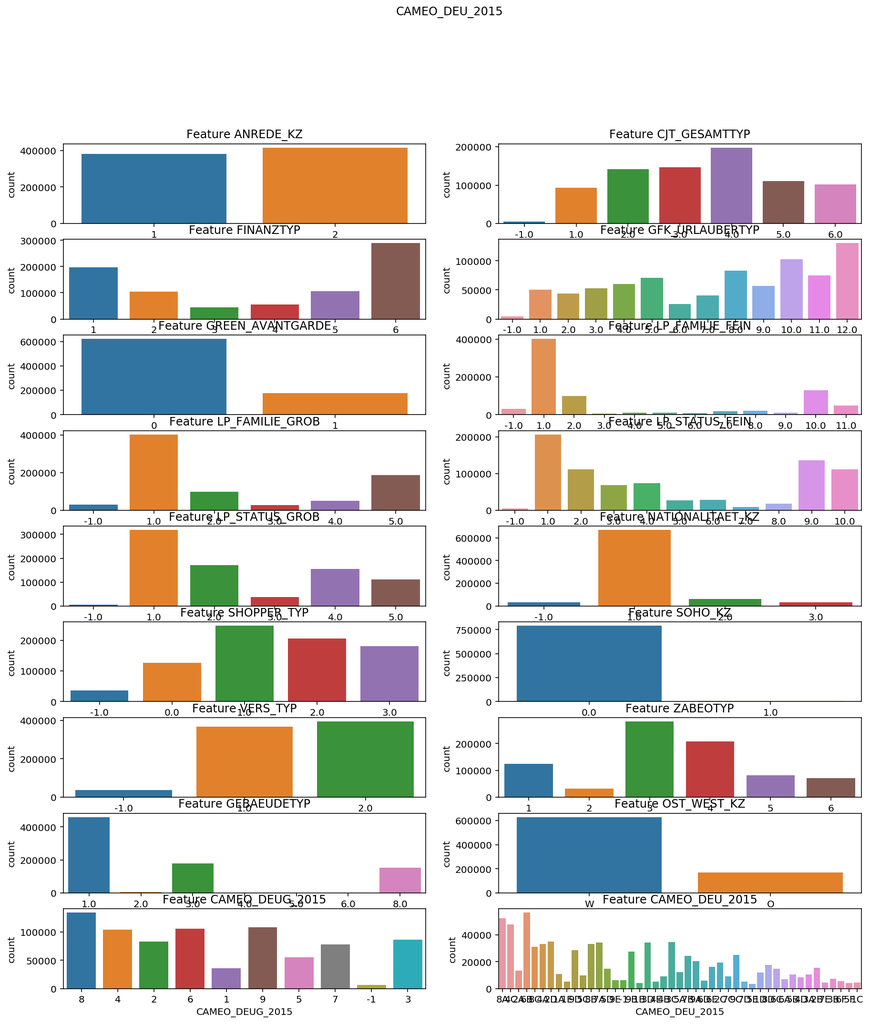

```python
plot_hist_feature(categorical_features)
```

```python
for c in categorical_features:
    print(f"Column {c}: After {azdias[c].unique()}")
```

```
Column ANREDE_KZ: After [2 1]
Column CJT_GESAMTTYP: After [ 5.  3.  2.  4.  1.  6. nan]
Column FINANZTYP: After [1 6 5 2 4 3]
Column GFK_URLAUBERTYP: After [10.  1.  5. 12.  9.  3.  8. 11.  4.  2.  7.  6. nan]
Column GREEN_AVANTGARDE: After [0 1]
Column LP_FAMILIE_FEIN: After [ 5.  1. nan 10.  2.  7. 11.  8.  4.  6.  9.  3.]
Column LP_FAMILIE_GROB: After [ 3.  1. nan  5.  2.  4.]
Column LP_STATUS_FEIN: After [ 2.  3.  9.  4.  1. 10.  5.  8.  6.  7. nan]
Column LP_STATUS_GROB: After [ 1.  2.  4.  5.  3. nan]
Column NATIONALITAET_KZ: After [ 1.  3.  2. nan]
Column SHOPPER_TYP: After [ 3.  2.  1.  0. nan]
Column SOHO_KZ: After [1. 0.]
Column VERS_TYP: After [ 2.  1. nan]
Column ZABEOTYP: After [5 3 4 1 6 2]
Column GEBAEUDETYP: After [8. 1. 3. 2. 6. 4. 5.]
Column OST_WEST_KZ: After ['W' 'O']
Column CAMEO_DEUG_2015: After ['8' '4' '2' '6' '1' '9' '5' '7' nan '3']
Column CAMEO_DEU_2015: After ['8A' '4C' '2A' '6B' '8C' '4A' '2D' '1A' '1E' '9D' '5C' '8B' '7A' '5D'
 '9E' nan '9B' '1B' '3D' '4E' '4B' '3C' '5A' '7B' '9A' '6D' '6E' '2C' '7C'
 '9C' '7D' '5E' '1D' '8D' '6C' '6A' '5B' '4D' '3A' '2B' '7E' '3B' '6F'
 '5F' '1C']
```

```python
# Drop features ANREDE_KZ and VERS_TYP -- flat histogram
azdias.drop(['ANREDE_KZ', 'VERS_TYP'], axis=1, inplace=True)
categorical_features = categorical_features[categorical_features != 'ANREDE_KZ']
categorical_features = categorical_features[categorical_features != 'VERS_TYP']
```

```python
binary_columns = []
multi_columns = []
for c in categorical_features:
    if azdias[c].unique().size == 2:
        binary_columns.append(c)
    else:
        multi_columns.append(c)
print(f"Nr binary columns: {len(binary_columns)}")
print(f"Nr Multi-level columns: {len(multi_columns)}")
```

```
Nr binary columns: 3
Nr Multi-level columns: 13
```

```python
# Checking the values of the binary columns and re-encode them.
for c in binary_columns:
    values = azdias[c].unique()
    azdias[c].replace(values, [0,1], inplace=True)
    print(f"Column {c}: {values} -> {azdias[c].unique()}")
```

```
Column GREEN_AVANTGARDE: [0 1] -> [0 1]
Column SOHO_KZ: [1. 0.] -> [0. 1.]
Column OST_WEST_KZ: ['W' 'O'] -> [0 1]
```

```python
# Re-encode categorical variable(s) to be kept in the analysis.
azdias = pd.get_dummies(azdias, columns=multi_columns, drop_first=True)
```

```python
azdias.describe()
```

|  | ALTERSKATEGORIE_GROB | FINANZ_MINIMALIST | FINANZ_SPARER | FINANZ_VORSORGER | FINANZ_ANLEGER | FINANZ_UNAUFFAELLIGER | FINANZ_HAUSBAUER | GREEN_AVANTGARDE | HEALTH_TYP | LP_LEBENSPHASE_FEIN | ... | CAMEO_DEU_2015_7E | CAMEO_DEU_2015_8A | CAMEO_DEU_2015_8B | CAMEO_DEU_2015_8C | CAMEO_DEU_2015_8D | CAMEO_DEU_2015_9A | CAMEO_DEU_2015_9B | CAMEO_DEU_2015_9C | CAMEO_DEU_2015_9D | CAMEO_DEU_2015_9E |
| --- | --- | --- | --- | --- | --- | --- | --- | --- | --- | --- | --- | --- | --- | --- | --- | --- | --- | --- | --- | --- | --- |
| count | 795160.000000 | 797961.000000 | 797961.000000 | 797961.000000 | 797961.000000 | 797961.000000 | 797961.000000 | 797961.000000 | 761281.000000 | 747828.000000 | ... | 797961.000000 | 797961.000000 | 797961.000000 | 797961.000000 | 797961.000000 | 797961.000000 | 797961.000000 | 797961.000000 | 797961.000000 | 797961.000000 |
| mean | 2.795403 | 3.058910 | 2.715979 | 3.432915 | 2.840878 | 2.658168 | 3.114269 | 0.219585 | 2.199036 | 16.310959 | ... | 0.005806 | 0.065714 | 0.041899 | 0.038839 | 0.022026 | 0.025743 | 0.034683 | 0.031314 | 0.035833 | 0.007993 |
| std | 1.018420 | 1.377562 | 1.485077 | 1.376892 | 1.472751 | 1.399466 | 1.408068 | 0.413966 | 0.755168 | 12.222719 | ... | 0.075976 | 0.247781 | 0.200359 | 0.193211 | 0.146769 | 0.158368 | 0.182977 | 0.174164 | 0.185873 | 0.089045 |
| min | 1.000000 | 1.000000 | 1.000000 | 1.000000 | 1.000000 | 1.000000 | 1.000000 | 0.000000 | 1.000000 | 1.000000 | ... | 0.000000 | 0.000000 | 0.000000 | 0.000000 | 0.000000 | 0.000000 | 0.000000 | 0.000000 | 0.000000 | 0.000000 |
| 25% | 2.000000 | 2.000000 | 1.000000 | 2.000000 | 1.000000 | 1.000000 | 2.000000 | 0.000000 | 2.000000 | 6.000000 | ... | 0.000000 | 0.000000 | 0.000000 | 0.000000 | 0.000000 | 0.000000 | 0.000000 | 0.000000 | 0.000000 | 0.000000 |
| 50% | 3.000000 | 3.000000 | 3.000000 | 4.000000 | 3.000000 | 2.000000 | 3.000000 | 0.000000 | 2.000000 | 13.000000 | ... | 0.000000 | 0.000000 | 0.000000 | 0.000000 | 0.000000 | 0.000000 | 0.000000 | 0.000000 | 0.000000 | 0.000000 |
| 75% | 4.000000 | 4.000000 | 4.000000 | 5.000000 | 4.000000 | 4.000000 | 4.000000 | 0.000000 | 3.000000 | 28.000000 | ... | 0.000000 | 0.000000 | 0.000000 | 0.000000 | 0.000000 | 0.000000 | 0.000000 | 0.000000 | 0.000000 | 0.000000 |
| max | 4.000000 | 5.000000 | 5.000000 | 5.000000 | 5.000000 | 5.000000 | 5.000000 | 1.000000 | 3.000000 | 40.000000 | ... | 1.000000 | 1.000000 | 1.000000 | 1.000000 | 1.000000 | 1.000000 | 1.000000 | 1.000000 | 1.000000 | 1.000000 |

8 rows × 178 columns

#### Discussion 1.2.1: Re-Encode Categorical Features

Of the 18 different categorical features, there are 2 binary features of which both equals are almost equally present in the data set: `ANREDE_KZ` and `VERS_TYP`. These features don't add much information and as such can be dropped.

Of the remaining features there are 3 binary and 13 multi-level. The binary columns were re-encoded using a simple `replace` on the DataFrame. The multi-level features were re-encoded using `pandas.get_dummies` in which I dropped the first category in order to limit the number of features added to the dataset.

#### Step 1.2.2: Engineer Mixed-Type Features

There are a handful of features that are marked as "mixed" in the feature summary that require special treatment in order to be included in the analysis. There are two in particular that deserve attention; the handling of the rest are up to your own choices:

- "PRAEGENDE_JUGENDJAHRE" combines information on three dimensions: generation by decade, movement (mainstream vs. avantgarde), and nation (east vs. west). While there aren't enough levels to disentangle east from west, you should create two new variables to capture the other two dimensions: an interval-type variable for decade, and a binary variable for movement.
- "CAMEO_INTL_2015" combines information on two axes: wealth and life stage. Break up the two-digit codes by their 'tens'-place and 'ones'-place digits into two new ordinal variables (which, for the purposes of this project, is equivalent to just treating them as their raw numeric values).
- If you decide to keep or engineer new features around the other mixed-type features, make sure you note your steps in the Discussion section.

Be sure to check `Data_Dictionary.md` for the details needed to finish these tasks.

```python
# Investigate "PRAEGENDE_JUGENDJAHRE" and engineer two new variables.
azdias['PRAEGENDE_JUGENDJAHRE'].head()
```

```
1    14.0
2    15.0
3     8.0
4     8.0
5     3.0
Name: PRAEGENDE_JUGENDJAHRE, dtype: float64
```

| value | generation | movement |
| --- | --- | --- |
| 1 | 0 - 40 | 0 - M |
| 2 | 0 - 40 | 1 - A |
| 3 | 1 - 50 | 0 - M |
| 4 | 1 - 50 | 1 - A |
| 5 | 2 - 60 | 0 - M |
| 6 | 2 - 60 | 1 - A |
| 7 | 2 - 60 | 1 - A |
| 8 | 3 - 70 | 0 - M |
| 9 | 3 - 70 | 1 - A |
| 10 | 4 - 80 | 0 - M |
| 11 | 4 - 80 | 1 - A |
| 12 | 4 - 80 | 0 - M |
| 13 | 4 - 80 | 1 - A |
| 14 | 5 - 90 | 0 - M |
| 15 | 5 - 90 | 1 - A |

```python
# Define dataframe containing mapping, so the azdias_enc and this new dataframe can be merged.
youth_data = {
    'PRAEGENDE_JUGENDJAHRE': [1.0, 2.0, 3.0, 4.0, 5.0, 6.0, 7.0, 8.0, 9.0, 10.0, 11.0, 12.0, 13.0, 14.0, 15.0],
    'PRAEGENDE_JUGENDJAHRE_generation': [0, 0, 1, 1, 2, 2, 2, 3, 3, 4, 4, 4, 4, 5, 5],
    'PRAEGENDE_JUGENDJAHRE_movement':   [0, 1, 0, 1, 0, 1, 1, 0, 1, 0, 1, 0, 1, 0, 1]
}
df_youth_map = pd.DataFrame(youth_data, columns=['PRAEGENDE_JUGENDJAHRE', 'PRAEGENDE_JUGENDJAHRE_generation', 'PRAEGENDE_JUGENDJAHRE_movement'])
df_youth_map
```

|  | PRAEGENDE_JUGENDJAHRE | PRAEGENDE_JUGENDJAHRE_generation | PRAEGENDE_JUGENDJAHRE_movement |
| --- | --- | --- | --- |
| 0 | 1.0 | 0 | 0 |
| 1 | 2.0 | 0 | 1 |
| 2 | 3.0 | 1 | 0 |
| 3 | 4.0 | 1 | 1 |
| 4 | 5.0 | 2 | 0 |
| 5 | 6.0 | 2 | 1 |
| 6 | 7.0 | 2 | 1 |
| 7 | 8.0 | 3 | 0 |
| 8 | 9.0 | 3 | 1 |
| 9 | 10.0 | 4 | 0 |
| 10 | 11.0 | 4 | 1 |
| 11 | 12.0 | 4 | 0 |
| 12 | 13.0 | 4 | 1 |
| 13 | 14.0 | 5 | 0 |
| 14 | 15.0 | 5 | 1 |

```python
azdias = azdias.merge(df_youth_map, on='PRAEGENDE_JUGENDJAHRE', how='left')
azdias[['PRAEGENDE_JUGENDJAHRE', 'PRAEGENDE_JUGENDJAHRE_generation', 'PRAEGENDE_JUGENDJAHRE_movement']]
```

|  | PRAEGENDE_JUGENDJAHRE | PRAEGENDE_JUGENDJAHRE_generation | PRAEGENDE_JUGENDJAHRE_movement |
| --- | --- | --- | --- |
| 0 | 14.0 | 5.0 | 0.0 |
| 1 | 15.0 | 5.0 | 1.0 |
| 2 | 8.0 | 3.0 | 0.0 |
| 3 | 8.0 | 3.0 | 0.0 |
| 4 | 3.0 | 1.0 | 0.0 |
| 5 | 10.0 | 4.0 | 0.0 |
| 6 | 8.0 | 3.0 | 0.0 |
| 7 | 11.0 | 4.0 | 1.0 |
| 8 | 15.0 | 5.0 | 1.0 |
| 9 | 3.0 | 1.0 | 0.0 |
| 10 | 8.0 | 3.0 | 0.0 |
| 11 | 15.0 | 5.0 | 1.0 |
| 12 | 5.0 | 2.0 | 0.0 |
| 13 | 14.0 | 5.0 | 0.0 |
| 14 | 10.0 | 4.0 | 0.0 |
| 15 | 9.0 | 3.0 | 1.0 |
| 16 | 11.0 | 4.0 | 1.0 |
| 17 | 10.0 | 4.0 | 0.0 |
| 18 | 14.0 | 5.0 | 0.0 |
| 19 | 9.0 | 3.0 | 1.0 |
| 20 | 14.0 | 5.0 | 0.0 |
| 21 | 8.0 | 3.0 | 0.0 |
| 22 | 11.0 | 4.0 | 1.0 |
| 23 | 10.0 | 4.0 | 0.0 |
| 24 | 6.0 | 2.0 | 1.0 |
| 25 | 10.0 | 4.0 | 0.0 |
| 26 | 15.0 | 5.0 | 1.0 |
| 27 | 8.0 | 3.0 | 0.0 |
| 28 | 4.0 | 1.0 | 1.0 |
| 29 | 8.0 | 3.0 | 0.0 |
| ... | ... | ... | ... |
| 797931 | 3.0 | 1.0 | 0.0 |
| 797932 | 14.0 | 5.0 | 0.0 |
| 797933 | 5.0 | 2.0 | 0.0 |
| 797934 | 11.0 | 4.0 | 1.0 |
| 797935 | 8.0 | 3.0 | 0.0 |
| 797936 | 14.0 | 5.0 | 0.0 |
| 797937 | 11.0 | 4.0 | 1.0 |
| 797938 | 15.0 | 5.0 | 1.0 |
| 797939 | 10.0 | 4.0 | 0.0 |
| 797940 | 14.0 | 5.0 | 0.0 |
| 797941 | 10.0 | 4.0 | 0.0 |
| 797942 | 10.0 | 4.0 | 0.0 |
| 797943 | NaN | NaN | NaN |
| 797944 | 10.0 | 4.0 | 0.0 |
| 797945 | 3.0 | 1.0 | 0.0 |
| 797946 | 14.0 | 5.0 | 0.0 |
| 797947 | 2.0 | 0.0 | 1.0 |
| 797948 | 8.0 | 3.0 | 0.0 |
| 797949 | 14.0 | 5.0 | 0.0 |
| 797950 | 8.0 | 3.0 | 0.0 |
| 797951 | 8.0 | 3.0 | 0.0 |
| 797952 | 3.0 | 1.0 | 0.0 |
| 797953 | 11.0 | 4.0 | 1.0 |
| 797954 | 14.0 | 5.0 | 0.0 |
| 797955 | 10.0 | 4.0 | 0.0 |
| 797956 | 14.0 | 5.0 | 0.0 |
| 797957 | 10.0 | 4.0 | 0.0 |
| 797958 | 14.0 | 5.0 | 0.0 |
| 797959 | 14.0 | 5.0 | 0.0 |
| 797960 | 3.0 | 1.0 | 0.0 |

797961 rows × 3 columns

```python
# Investigate "CAMEO_INTL_2015" and engineer two new variables.
azdias['CAMEO_INTL_2015'].head()
```

```
0    51
1    24
2    12
3    43
4    54
Name: CAMEO_INTL_2015, dtype: object
```

```python
value = []
wealth = []
lifestage = []
for i in range(1, 6):
    for j in range(1, 6):
        value.append(str(i*10 + j))
        wealth.append(i)
        lifestage.append(j)

cameo_data = {
    'CAMEO_INTL_2015': value,
    'CAMEO_INTL_2015_wealth': wealth,
    'CAMEO_INTL_2015_lifestage': lifestage
}

df_wealth_map = pd.DataFrame(cameo_data, columns=['CAMEO_INTL_2015', 'CAMEO_INTL_2015_wealth', 'CAMEO_INTL_2015_lifestage'])
df_wealth_map
```

|  | CAMEO_INTL_2015 | CAMEO_INTL_2015_wealth | CAMEO_INTL_2015_lifestage |
| --- | --- | --- | --- |
| 0 | 11 | 1 | 1 |
| 1 | 12 | 1 | 2 |
| 2 | 13 | 1 | 3 |
| 3 | 14 | 1 | 4 |
| 4 | 15 | 1 | 5 |
| 5 | 21 | 2 | 1 |
| 6 | 22 | 2 | 2 |
| 7 | 23 | 2 | 3 |
| 8 | 24 | 2 | 4 |
| 9 | 25 | 2 | 5 |
| 10 | 31 | 3 | 1 |
| 11 | 32 | 3 | 2 |
| 12 | 33 | 3 | 3 |
| 13 | 34 | 3 | 4 |
| 14 | 35 | 3 | 5 |
| 15 | 41 | 4 | 1 |
| 16 | 42 | 4 | 2 |
| 17 | 43 | 4 | 3 |
| 18 | 44 | 4 | 4 |
| 19 | 45 | 4 | 5 |
| 20 | 51 | 5 | 1 |
| 21 | 52 | 5 | 2 |
| 22 | 53 | 5 | 3 |
| 23 | 54 | 5 | 4 |
| 24 | 55 | 5 | 5 |

```python
azdias = azdias.merge(df_wealth_map, on='CAMEO_INTL_2015', how='left')
azdias[['CAMEO_INTL_2015', 'CAMEO_INTL_2015_wealth', 'CAMEO_INTL_2015_lifestage']]
```

|  | CAMEO_INTL_2015 | CAMEO_INTL_2015_wealth | CAMEO_INTL_2015_lifestage |
| --- | --- | --- | --- |
| 0 | 51 | 5.0 | 1.0 |
| 1 | 24 | 2.0 | 4.0 |
| 2 | 12 | 1.0 | 2.0 |
| 3 | 43 | 4.0 | 3.0 |
| 4 | 54 | 5.0 | 4.0 |
| 5 | 22 | 2.0 | 2.0 |
| 6 | 14 | 1.0 | 4.0 |
| 7 | 13 | 1.0 | 3.0 |
| 8 | 15 | 1.0 | 5.0 |
| 9 | 51 | 5.0 | 1.0 |
| 10 | 43 | 4.0 | 3.0 |
| 11 | 33 | 3.0 | 3.0 |
| 12 | 41 | 4.0 | 1.0 |
| 13 | 41 | 4.0 | 1.0 |
| 14 | 24 | 2.0 | 4.0 |
| 15 | 34 | 3.0 | 4.0 |
| 16 | 24 | 2.0 | 4.0 |
| 17 | 55 | 5.0 | 5.0 |
| 18 | 51 | 5.0 | 1.0 |
| 19 | 43 | 4.0 | 3.0 |
| 20 | 33 | 3.0 | 3.0 |
| 21 | NaN | NaN | NaN |
| 22 | 51 | 5.0 | 1.0 |
| 23 | 13 | 1.0 | 3.0 |
| 24 | 12 | 1.0 | 2.0 |
| 25 | 51 | 5.0 | 1.0 |
| 26 | 14 | 1.0 | 4.0 |
| 27 | 41 | 4.0 | 1.0 |
| 28 | 25 | 2.0 | 5.0 |
| 29 | 41 | 4.0 | 1.0 |
| ... | ... | ... | ... |
| 797931 | 44 | 4.0 | 4.0 |
| 797932 | 32 | 3.0 | 2.0 |
| 797933 | 43 | 4.0 | 3.0 |
| 797934 | 24 | 2.0 | 4.0 |
| 797935 | 55 | 5.0 | 5.0 |
| 797936 | 23 | 2.0 | 3.0 |
| 797937 | 24 | 2.0 | 4.0 |
| 797938 | 14 | 1.0 | 4.0 |
| 797939 | 51 | 5.0 | 1.0 |
| 797940 | 52 | 5.0 | 2.0 |
| 797941 | 41 | 4.0 | 1.0 |
| 797942 | 41 | 4.0 | 1.0 |
| 797943 | 25 | 2.0 | 5.0 |
| 797944 | 24 | 2.0 | 4.0 |
| 797945 | 34 | 3.0 | 4.0 |
| 797946 | 25 | 2.0 | 5.0 |
| 797947 | 41 | 4.0 | 1.0 |
| 797948 | 14 | 1.0 | 4.0 |
| 797949 | 51 | 5.0 | 1.0 |
| 797950 | 41 | 4.0 | 1.0 |
| 797951 | 51 | 5.0 | 1.0 |
| 797952 | 51 | 5.0 | 1.0 |
| 797953 | 34 | 3.0 | 4.0 |
| 797954 | 23 | 2.0 | 3.0 |
| 797955 | 31 | 3.0 | 1.0 |
| 797956 | 41 | 4.0 | 1.0 |
| 797957 | 51 | 5.0 | 1.0 |
| 797958 | 24 | 2.0 | 4.0 |
| 797959 | 51 | 5.0 | 1.0 |
| 797960 | 43 | 4.0 | 3.0 |

797961 rows × 3 columns

```python
# Drop the original features
azdias.drop(['PRAEGENDE_JUGENDJAHRE', 'CAMEO_INTL_2015'], axis=1, inplace=True)
```

#### Discussion 1.2.2: Engineer Mixed-Type Features

Of the feature `PRAEGENDE_JUGENDJAHRE`, 2 out of the 3 dimensions were turned into additional features: `PRAEGENDE_JUGENDJAHRE_generation` and `PRAEGENDE_JUGENDJAHRE_movement`. The features were added by defining a DataFrame containing the mapping for these additional feature and using the pandas `merge()` function. The 3rd dimensions was dropped as instructed.

The feature `CAMEO_INTL_2015` contains 2 dimensions for both an additional feature was added: `CAMEO_INTL_2015_wealth` and `CAMEO_INTL_2015_lifestage`. The features were added using a similar approach as the first feature.

#### Step 1.2.3: Complete Feature Selection

In order to finish this step up, you need to make sure that your data frame now only has the columns that you want to keep. To summarize, the dataframe should consist of the following:

- All numeric, interval, and ordinal type columns from the original dataset.
- Binary categorical features (all numerically-encoded).
- Engineered features from other multi-level categorical features and mixed features.

Make sure that for any new columns that you have engineered, that you've excluded the original columns from the final dataset. Otherwise, their values will interfere with the analysis later on the project. For example, you should not keep "PRAEGENDE_JUGENDJAHRE", since its values won't be useful for the algorithm: only the values derived from it in the engineered features you created should be retained. As a reminder, your data should only be from **the subset with few or no missing values**.

```python
# If there are other re-engineering tasks you need to perform, make sure you
# take care of them here. (Dealing with missing data will come in step 2.1.)

# Checking the types of each of the features in the dataset
np.unique(azdias.dtypes.values)
```

```
array([dtype('uint8'), dtype('int64'), dtype('float64')], dtype=object)
```

```python
# Checking the feature names.
azdias.columns.values
```

```
array(['ALTERSKATEGORIE_GROB', 'FINANZ_MINIMALIST', 'FINANZ_SPARER',
       'FINANZ_VORSORGER', 'FINANZ_ANLEGER', 'FINANZ_UNAUFFAELLIGER',
       'FINANZ_HAUSBAUER', 'GREEN_AVANTGARDE', 'HEALTH_TYP',
       'LP_LEBENSPHASE_FEIN', 'LP_LEBENSPHASE_GROB', 'RETOURTYP_BK_S',
       'SEMIO_SOZ', 'SEMIO_FAM', 'SEMIO_REL', 'SEMIO_MAT', 'SEMIO_VERT',
       'SEMIO_LUST', 'SEMIO_ERL', 'SEMIO_KULT', 'SEMIO_RAT', 'SEMIO_KRIT',
       'SEMIO_DOM', 'SEMIO_KAEM', 'SEMIO_PFLICHT', 'SEMIO_TRADV',
       'SOHO_KZ', 'ANZ_PERSONEN', 'ANZ_TITEL', 'HH_EINKOMMEN_SCORE',
       'W_KEIT_KIND_HH', 'WOHNDAUER_2008', 'ANZ_HAUSHALTE_AKTIV',
       'ANZ_HH_TITEL', 'KONSUMNAEHE', 'MIN_GEBAEUDEJAHR', 'OST_WEST_KZ',
       'WOHNLAGE', 'KBA05_ANTG1', 'KBA05_ANTG2', 'KBA05_ANTG3',
       'KBA05_ANTG4', 'KBA05_GBZ', 'BALLRAUM', 'EWDICHTE', 'INNENSTADT',
       'GEBAEUDETYP_RASTER', 'KKK', 'MOBI_REGIO', 'ONLINE_AFFINITAET',
       'REGIOTYP', 'KBA13_ANZAHL_PKW', 'PLZ8_ANTG1', 'PLZ8_ANTG2',
       'PLZ8_ANTG3', 'PLZ8_ANTG4', 'PLZ8_BAUMAX', 'PLZ8_HHZ', 'PLZ8_GBZ',
       'ARBEIT', 'ORTSGR_KLS9', 'RELAT_AB', 'CJT_GESAMTTYP_2.0',
       'CJT_GESAMTTYP_3.0', 'CJT_GESAMTTYP_4.0', 'CJT_GESAMTTYP_5.0',
       'CJT_GESAMTTYP_6.0', 'FINANZTYP_2', 'FINANZTYP_3', 'FINANZTYP_4',
       'FINANZTYP_5', 'FINANZTYP_6', 'GFK_URLAUBERTYP_2.0',
       'GFK_URLAUBERTYP_3.0', 'GFK_URLAUBERTYP_4.0',
       'GFK_URLAUBERTYP_5.0', 'GFK_URLAUBERTYP_6.0',
       'GFK_URLAUBERTYP_7.0', 'GFK_URLAUBERTYP_8.0',
       'GFK_URLAUBERTYP_9.0', 'GFK_URLAUBERTYP_10.0',
       'GFK_URLAUBERTYP_11.0', 'GFK_URLAUBERTYP_12.0',
       'LP_FAMILIE_FEIN_2.0', 'LP_FAMILIE_FEIN_3.0',
       'LP_FAMILIE_FEIN_4.0', 'LP_FAMILIE_FEIN_5.0',
       'LP_FAMILIE_FEIN_6.0', 'LP_FAMILIE_FEIN_7.0',
       'LP_FAMILIE_FEIN_8.0', 'LP_FAMILIE_FEIN_9.0',
       'LP_FAMILIE_FEIN_10.0', 'LP_FAMILIE_FEIN_11.0',
       'LP_FAMILIE_GROB_2.0', 'LP_FAMILIE_GROB_3.0',
       'LP_FAMILIE_GROB_4.0', 'LP_FAMILIE_GROB_5.0', 'LP_STATUS_FEIN_2.0',
       'LP_STATUS_FEIN_3.0', 'LP_STATUS_FEIN_4.0', 'LP_STATUS_FEIN_5.0',
       'LP_STATUS_FEIN_6.0', 'LP_STATUS_FEIN_7.0', 'LP_STATUS_FEIN_8.0',
       'LP_STATUS_FEIN_9.0', 'LP_STATUS_FEIN_10.0', 'LP_STATUS_GROB_2.0',
       'LP_STATUS_GROB_3.0', 'LP_STATUS_GROB_4.0', 'LP_STATUS_GROB_5.0',
       'NATIONALITAET_KZ_2.0', 'NATIONALITAET_KZ_3.0', 'SHOPPER_TYP_1.0',
       'SHOPPER_TYP_2.0', 'SHOPPER_TYP_3.0', 'ZABEOTYP_2', 'ZABEOTYP_3',
       'ZABEOTYP_4', 'ZABEOTYP_5', 'ZABEOTYP_6', 'GEBAEUDETYP_2.0',
       'GEBAEUDETYP_3.0', 'GEBAEUDETYP_4.0', 'GEBAEUDETYP_5.0',
       'GEBAEUDETYP_6.0', 'GEBAEUDETYP_8.0', 'CAMEO_DEUG_2015_2',
       'CAMEO_DEUG_2015_3', 'CAMEO_DEUG_2015_4', 'CAMEO_DEUG_2015_5',
       'CAMEO_DEUG_2015_6', 'CAMEO_DEUG_2015_7', 'CAMEO_DEUG_2015_8',
       'CAMEO_DEUG_2015_9', 'CAMEO_DEU_2015_1B', 'CAMEO_DEU_2015_1C',
       'CAMEO_DEU_2015_1D', 'CAMEO_DEU_2015_1E', 'CAMEO_DEU_2015_2A',
       'CAMEO_DEU_2015_2B', 'CAMEO_DEU_2015_2C', 'CAMEO_DEU_2015_2D',
       'CAMEO_DEU_2015_3A', 'CAMEO_DEU_2015_3B', 'CAMEO_DEU_2015_3C',
       'CAMEO_DEU_2015_3D', 'CAMEO_DEU_2015_4A', 'CAMEO_DEU_2015_4B',
       'CAMEO_DEU_2015_4C', 'CAMEO_DEU_2015_4D', 'CAMEO_DEU_2015_4E',
       'CAMEO_DEU_2015_5A', 'CAMEO_DEU_2015_5B', 'CAMEO_DEU_2015_5C',
       'CAMEO_DEU_2015_5D', 'CAMEO_DEU_2015_5E', 'CAMEO_DEU_2015_5F',
       'CAMEO_DEU_2015_6A', 'CAMEO_DEU_2015_6B', 'CAMEO_DEU_2015_6C',
       'CAMEO_DEU_2015_6D', 'CAMEO_DEU_2015_6E', 'CAMEO_DEU_2015_6F',
       'CAMEO_DEU_2015_7A', 'CAMEO_DEU_2015_7B', 'CAMEO_DEU_2015_7C',
       'CAMEO_DEU_2015_7D', 'CAMEO_DEU_2015_7E', 'CAMEO_DEU_2015_8A',
       'CAMEO_DEU_2015_8B', 'CAMEO_DEU_2015_8C', 'CAMEO_DEU_2015_8D',
       'CAMEO_DEU_2015_9A', 'CAMEO_DEU_2015_9B', 'CAMEO_DEU_2015_9C',
       'CAMEO_DEU_2015_9D', 'CAMEO_DEU_2015_9E',
       'PRAEGENDE_JUGENDJAHRE_generation',
       'PRAEGENDE_JUGENDJAHRE_movement', 'CAMEO_INTL_2015_wealth',
       'CAMEO_INTL_2015_lifestage'], dtype=object)
```

```python
azdias
```

|  | ALTERSKATEGORIE_GROB | FINANZ_MINIMALIST | FINANZ_SPARER | FINANZ_VORSORGER | FINANZ_ANLEGER | FINANZ_UNAUFFAELLIGER | FINANZ_HAUSBAUER | GREEN_AVANTGARDE | HEALTH_TYP | LP_LEBENSPHASE_FEIN | ... | CAMEO_DEU_2015_8D | CAMEO_DEU_2015_9A | CAMEO_DEU_2015_9B | CAMEO_DEU_2015_9C | CAMEO_DEU_2015_9D | CAMEO_DEU_2015_9E | PRAEGENDE_JUGENDJAHRE_generation | PRAEGENDE_JUGENDJAHRE_movement | CAMEO_INTL_2015_wealth | CAMEO_INTL_2015_lifestage |
| --- | --- | --- | --- | --- | --- | --- | --- | --- | --- | --- | --- | --- | --- | --- | --- | --- | --- | --- | --- | --- | --- |
| 0 | 1.0 | 1 | 5 | 2 | 5 | 4 | 5 | 0 | 3.0 | 21.0 | ... | 0 | 0 | 0 | 0 | 0 | 0 | 5.0 | 0.0 | 5.0 | 1.0 |
| 1 | 3.0 | 1 | 4 | 1 | 2 | 3 | 5 | 1 | 3.0 | 3.0 | ... | 0 | 0 | 0 | 0 | 0 | 0 | 5.0 | 1.0 | 2.0 | 4.0 |
| 2 | 4.0 | 4 | 2 | 5 | 2 | 1 | 2 | 0 | 2.0 | NaN | ... | 0 | 0 | 0 | 0 | 0 | 0 | 3.0 | 0.0 | 1.0 | 2.0 |
| 3 | 3.0 | 4 | 3 | 4 | 1 | 3 | 2 | 0 | 3.0 | 32.0 | ... | 0 | 0 | 0 | 0 | 0 | 0 | 3.0 | 0.0 | 4.0 | 3.0 |
| 4 | 1.0 | 3 | 1 | 5 | 2 | 2 | 5 | 0 | 3.0 | 8.0 | ... | 0 | 0 | 0 | 0 | 0 | 0 | 1.0 | 0.0 | 5.0 | 4.0 |
| 5 | 2.0 | 1 | 5 | 1 | 5 | 4 | 3 | 0 | 2.0 | 2.0 | ... | 0 | 0 | 0 | 0 | 0 | 0 | 4.0 | 0.0 | 2.0 | 2.0 |
| 6 | 1.0 | 3 | 3 | 4 | 1 | 3 | 2 | 0 | 1.0 | 5.0 | ... | 0 | 0 | 0 | 0 | 0 | 0 | 3.0 | 0.0 | 1.0 | 4.0 |
| 7 | 3.0 | 4 | 4 | 2 | 4 | 2 | 2 | 1 | 3.0 | 10.0 | ... | 0 | 0 | 0 | 0 | 0 | 0 | 4.0 | 1.0 | 1.0 | 3.0 |
| 8 | 3.0 | 2 | 4 | 2 | 3 | 5 | 4 | 1 | 2.0 | 4.0 | ... | 0 | 0 | 0 | 0 | 0 | 0 | 5.0 | 1.0 | 1.0 | 5.0 |
| 9 | 3.0 | 2 | 2 | 5 | 3 | 1 | 5 | 0 | 2.0 | 6.0 | ... | 0 | 0 | 0 | 0 | 1 | 0 | 1.0 | 0.0 | 5.0 | 1.0 |
| 10 | 3.0 | 5 | 3 | 4 | 2 | 4 | 1 | 0 | 1.0 | 23.0 | ... | 0 | 0 | 0 | 0 | 0 | 0 | 3.0 | 0.0 | 4.0 | 3.0 |
| 11 | 1.0 | 1 | 4 | 3 | 5 | 5 | 2 | 1 | 3.0 | 3.0 | ... | 0 | 0 | 0 | 0 | 0 | 0 | 5.0 | 1.0 | 3.0 | 3.0 |
| 12 | 4.0 | 4 | 1 | 5 | 1 | 1 | 4 | 0 | 2.0 | 12.0 | ... | 0 | 0 | 0 | 0 | 0 | 0 | 2.0 | 0.0 | 4.0 | 1.0 |
| 13 | 1.0 | 4 | 3 | 1 | 4 | 5 | 1 | 0 | 3.0 | NaN | ... | 0 | 0 | 0 | 0 | 0 | 0 | 5.0 | 0.0 | 4.0 | 1.0 |
| 14 | 2.0 | 2 | 4 | 1 | 5 | 4 | 1 | 0 | 2.0 | 10.0 | ... | 0 | 0 | 0 | 0 | 0 | 0 | 4.0 | 0.0 | 2.0 | 4.0 |
| 15 | 3.0 | 5 | 2 | 3 | 1 | 3 | 1 | 1 | 3.0 | 20.0 | ... | 0 | 0 | 0 | 0 | 0 | 0 | 3.0 | 1.0 | 3.0 | 4.0 |
| 16 | 2.0 | 4 | 3 | 1 | 4 | 5 | 1 | 1 | 3.0 | 10.0 | ... | 0 | 0 | 0 | 0 | 0 | 0 | 4.0 | 1.0 | 2.0 | 4.0 |
| 17 | 2.0 | 3 | 4 | 1 | 2 | 5 | 1 | 0 | 2.0 | 10.0 | ... | 0 | 0 | 0 | 0 | 0 | 1 | 4.0 | 0.0 | 5.0 | 5.0 |
| 18 | 1.0 | 1 | 5 | 3 | 5 | 5 | 5 | 0 | 2.0 | 1.0 | ... | 0 | 0 | 0 | 0 | 1 | 0 | 5.0 | 0.0 | 5.0 | 1.0 |
| 19 | 3.0 | 5 | 3 | 3 | 2 | 2 | 1 | 1 | 3.0 | 20.0 | ... | 0 | 0 | 0 | 0 | 0 | 0 | 3.0 | 1.0 | 4.0 | 3.0 |
| 20 | 1.0 | 3 | 5 | 3 | 5 | 4 | 3 | 0 | 2.0 | NaN | ... | 0 | 0 | 0 | 0 | 0 | 0 | 5.0 | 0.0 | 3.0 | 3.0 |
| 21 | 3.0 | 5 | 2 | 4 | 2 | 3 | 1 | 0 | 1.0 | 11.0 | ... | 0 | 0 | 0 | 0 | 0 | 0 | 3.0 | 0.0 | NaN | NaN |
| 22 | 3.0 | 3 | 3 | 4 | 1 | 2 | 2 | 1 | 3.0 | 25.0 | ... | 0 | 0 | 1 | 0 | 0 | 0 | 4.0 | 1.0 | 5.0 | 1.0 |
| 23 | 3.0 | 3 | 2 | 4 | 3 | 3 | 2 | 0 | 3.0 | 5.0 | ... | 0 | 0 | 0 | 0 | 0 | 0 | 4.0 | 0.0 | 1.0 | 3.0 |
| 24 | 4.0 | 5 | 1 | 5 | 2 | 1 | 3 | 1 | 2.0 | 13.0 | ... | 0 | 0 | 0 | 0 | 0 | 0 | 2.0 | 1.0 | 1.0 | 2.0 |
| 25 | 2.0 | 1 | 5 | 2 | 3 | 5 | 4 | 0 | 1.0 | 2.0 | ... | 0 | 0 | 0 | 0 | 1 | 0 | 4.0 | 0.0 | 5.0 | 1.0 |
| 26 | 1.0 | 5 | 4 | 2 | 3 | 4 | 1 | 1 | 1.0 | 18.0 | ... | 0 | 0 | 0 | 0 | 0 | 0 | 5.0 | 1.0 | 1.0 | 4.0 |
| 27 | 2.0 | 2 | 2 | 4 | 1 | 3 | 4 | 0 | 2.0 | 31.0 | ... | 0 | 0 | 0 | 0 | 0 | 0 | 3.0 | 0.0 | 4.0 | 1.0 |
| 28 | 1.0 | 4 | 1 | 5 | 1 | 2 | 3 | 1 | NaN | 13.0 | ... | 0 | 0 | 0 | 0 | 0 | 0 | 1.0 | 1.0 | 2.0 | 5.0 |
| 29 | 3.0 | 2 | 3 | 4 | 3 | 2 | 3 | 0 | 2.0 | 5.0 | ... | 0 | 0 | 0 | 0 | 0 | 0 | 3.0 | 0.0 | 4.0 | 1.0 |
| ... | ... | ... | ... | ... | ... | ... | ... | ... | ... | ... | ... | ... | ... | ... | ... | ... | ... | ... | ... | ... | ... |
| 797931 | 4.0 | 4 | 1 | 5 | 1 | 1 | 4 | 0 | 2.0 | 8.0 | ... | 0 | 0 | 0 | 0 | 0 | 0 | 1.0 | 0.0 | 4.0 | 4.0 |
| 797932 | 1.0 | 1 | 5 | 2 | 5 | 3 | 5 | 0 | 1.0 | 29.0 | ... | 0 | 0 | 0 | 0 | 0 | 0 | 5.0 | 0.0 | 3.0 | 2.0 |
| 797933 | 4.0 | 4 | 1 | 5 | 1 | 2 | 5 | 0 | 2.0 | 16.0 | ... | 0 | 0 | 0 | 0 | 0 | 0 | 2.0 | 0.0 | 4.0 | 3.0 |
| 797934 | 3.0 | 4 | 3 | 4 | 2 | 3 | 1 | 1 | 3.0 | 28.0 | ... | 0 | 0 | 0 | 0 | 0 | 0 | 4.0 | 1.0 | 2.0 | 4.0 |
| 797935 | 4.0 | 3 | 1 | 5 | 1 | 1 | 5 | 0 | 2.0 | 32.0 | ... | 1 | 0 | 0 | 0 | 0 | 0 | 3.0 | 0.0 | 5.0 | 5.0 |
| 797936 | 2.0 | 1 | 5 | 2 | 5 | 4 | 3 | 0 | 2.0 | 25.0 | ... | 0 | 0 | 0 | 0 | 0 | 0 | 5.0 | 0.0 | 2.0 | 3.0 |
| 797937 | 3.0 | 3 | 2 | 4 | 1 | 3 | 3 | 1 | 1.0 | 13.0 | ... | 0 | 0 | 0 | 0 | 0 | 0 | 4.0 | 1.0 | 2.0 | 4.0 |
| 797938 | 3.0 | 2 | 5 | 3 | 4 | 5 | 3 | 1 | 3.0 | 3.0 | ... | 0 | 0 | 0 | 0 | 0 | 0 | 5.0 | 1.0 | 1.0 | 4.0 |
| 797939 | 2.0 | 2 | 5 | 2 | 3 | 3 | 4 | 0 | 3.0 | 2.0 | ... | 0 | 0 | 0 | 0 | 0 | 0 | 4.0 | 0.0 | 5.0 | 1.0 |
| 797940 | 1.0 | 1 | 5 | 3 | 5 | 5 | 5 | 0 | 3.0 | 29.0 | ... | 0 | 1 | 0 | 0 | 0 | 0 | 5.0 | 0.0 | 5.0 | 2.0 |
| 797941 | 3.0 | 4 | 2 | 3 | 2 | 2 | 3 | 0 | 3.0 | 4.0 | ... | 0 | 0 | 0 | 0 | 0 | 0 | 4.0 | 0.0 | 4.0 | 1.0 |
| 797942 | 2.0 | 1 | 4 | 1 | 2 | 5 | 4 | 0 | 2.0 | 2.0 | ... | 0 | 0 | 0 | 0 | 0 | 0 | 4.0 | 0.0 | 4.0 | 1.0 |
| 797943 | 4.0 | 4 | 1 | 5 | 1 | 3 | 4 | 0 | 2.0 | NaN | ... | 0 | 0 | 0 | 0 | 0 | 0 | NaN | NaN | 2.0 | 5.0 |
| 797944 | 3.0 | 4 | 3 | 4 | 4 | 2 | 1 | 0 | 3.0 | 34.0 | ... | 0 | 0 | 0 | 0 | 0 | 0 | 4.0 | 0.0 | 2.0 | 4.0 |
| 797945 | 4.0 | 4 | 2 | 4 | 3 | 3 | 4 | 0 | 2.0 | 31.0 | ... | 0 | 0 | 0 | 0 | 0 | 0 | 1.0 | 0.0 | 3.0 | 4.0 |
| 797946 | 1.0 | 3 | 4 | 2 | 4 | 4 | 2 | 0 | 3.0 | 10.0 | ... | 0 | 0 | 0 | 0 | 0 | 0 | 5.0 | 0.0 | 2.0 | 5.0 |
| 797947 | 3.0 | 5 | 1 | 5 | 1 | 2 | 4 | 1 | 1.0 | 20.0 | ... | 0 | 0 | 0 | 0 | 0 | 0 | 0.0 | 1.0 | 4.0 | 1.0 |
| 797948 | 4.0 | 5 | 2 | 4 | 2 | 3 | 1 | 0 | 1.0 | 19.0 | ... | 0 | 0 | 0 | 0 | 0 | 0 | 3.0 | 0.0 | 1.0 | 4.0 |
| 797949 | 1.0 | 1 | 4 | 2 | 3 | 4 | 4 | 0 | 3.0 | 29.0 | ... | 0 | 0 | 0 | 0 | 0 | 0 | 5.0 | 0.0 | 5.0 | 1.0 |
| 797950 | 3.0 | 3 | 3 | 4 | 2 | 2 | 2 | 0 | 3.0 | 5.0 | ... | 0 | 0 | 0 | 0 | 0 | 0 | 3.0 | 0.0 | 4.0 | 1.0 |
| 797951 | 3.0 | 3 | 2 | 4 | 3 | 3 | 2 | 0 | 3.0 | 5.0 | ... | 0 | 0 | 0 | 0 | 1 | 0 | 3.0 | 0.0 | 5.0 | 1.0 |
| 797952 | 4.0 | 3 | 1 | 5 | 1 | 1 | 5 | 0 | 1.0 | 6.0 | ... | 0 | 0 | 0 | 0 | 1 | 0 | 1.0 | 0.0 | 5.0 | 1.0 |
| 797953 | 4.0 | 3 | 3 | 3 | 5 | 3 | 2 | 1 | 1.0 | 36.0 | ... | 0 | 0 | 0 | 0 | 0 | 0 | 4.0 | 1.0 | 3.0 | 4.0 |
| 797954 | 1.0 | 1 | 5 | 2 | 3 | 3 | 4 | 0 | 3.0 | 2.0 | ... | 0 | 0 | 0 | 0 | 0 | 0 | 5.0 | 0.0 | 2.0 | 3.0 |
| 797955 | 2.0 | 1 | 5 | 2 | 4 | 5 | 4 | 0 | 2.0 | 2.0 | ... | 0 | 0 | 0 | 0 | 0 | 0 | 4.0 | 0.0 | 3.0 | 1.0 |
| 797956 | 3.0 | 1 | 4 | 2 | 5 | 4 | 4 | 0 | 3.0 | 2.0 | ... | 0 | 0 | 0 | 0 | 0 | 0 | 5.0 | 0.0 | 4.0 | 1.0 |
| 797957 | 2.0 | 3 | 3 | 3 | 2 | 2 | 3 | 0 | NaN | 2.0 | ... | 0 | 0 | 0 | 0 | 1 | 0 | 4.0 | 0.0 | 5.0 | 1.0 |
| 797958 | 2.0 | 2 | 4 | 2 | 5 | 4 | 3 | 0 | 1.0 | NaN | ... | 0 | 0 | 0 | 0 | 0 | 0 | 5.0 | 0.0 | 2.0 | 4.0 |
| 797959 | 1.0 | 1 | 5 | 3 | 5 | 5 | 5 | 0 | 1.0 | 29.0 | ... | 0 | 0 | 0 | 0 | 1 | 0 | 5.0 | 0.0 | 5.0 | 1.0 |
| 797960 | 4.0 | 4 | 2 | 5 | 2 | 1 | 5 | 0 | 2.0 | 6.0 | ... | 0 | 0 | 0 | 0 | 0 | 0 | 1.0 | 0.0 | 4.0 | 3.0 |

797961 rows × 181 columns

### Step 1.3: Create a Cleaning Function

Even though you've finished cleaning up the general population demographics data, it's important to look ahead to the future and realize that you'll need to perform the same cleaning steps on the customer demographics data. In this substep, complete the function below to execute the main feature selection, encoding, and re-engineering steps you performed above. Then, when it comes to looking at the customer data in Step 3, you can just run this function on that DataFrame to get the trimmed dataset in a single step.

```python
def clean_data(df):
    """
    Perform feature trimming, re-encoding, and engineering for demographics
    data

    INPUT: Demographics DataFrame
    OUTPUT: Trimmed and cleaned demographics DataFrame
    """

    # Put in code here to execute all main cleaning steps:
    # convert missing value codes into NaNs, ...
    print("Converting missing/unknown values into NaN...")
    for i, c in enumerate(df.columns):
        #print(f"  Column {c}")
        df[c].replace(feat_info["missing_or_unknown_converted"][i], np.nan, inplace=True)

    # remove selected columns and rows, ...
    # -- Drop outlier columns
    print("Dropping outlier columns...")
    drop_columns = ['AGER_TYP', 'GEBURTSJAHR', 'TITEL_KZ', 'ALTER_HH', 'KK_KUNDENTYP', 'KBA05_BAUMAX']
    #print(f"  Columns: {drop_columns}")
    df.drop(drop_columns, axis=1, inplace=True)

    # -- Drop rows many missing features
    print("Dropping rows many missing features...")
    missing_rows = df.isnull().sum(axis=1)
    missing_rows_many = missing_rows[missing_rows > 25]
    missing_rows_few = missing_rows[missing_rows <= 25]
    print(f"  Rows dropping: {missing_rows_many.shape[0]}")
    df_missing_rows_many = df.iloc[missing_rows_many.index]
    df.drop(missing_rows_many.index, axis=0, inplace=True)

    # -- Binary features
    print("Re-encode binary features...")
    # dropping binary features with flat distribution.
    df.drop(['ANREDE_KZ', 'VERS_TYP'], axis=1, inplace=True)
    # re-encoding values of remaining binary features.
    for c in binary_columns:
        values = df[c].unique()
        df[c].replace(values, [0,1], inplace=True)
        print(f"  Column {c}: {values} -> {df[c].unique()}")

    print("Re-encode multi-level features...")
    df = pd.get_dummies(df, columns=multi_columns, drop_first=True)

    # select, re-encode, and engineer column values.
    print("Re-encode mixed-values features...")
    df = df.merge(df_youth_map, on='PRAEGENDE_JUGENDJAHRE', how='left')
    df = df.merge(df_wealth_map, on='CAMEO_INTL_2015', how='left')

    df.drop(['PRAEGENDE_JUGENDJAHRE', 'CAMEO_INTL_2015'], axis=1, inplace=True)

    # Return the cleaned dataframe.
    return df, df_missing_rows_many
```

```python
# Reloading original dataset, running clean fuction and comparing dimensions
general = pd.read_csv("./data/Udacity_AZDIAS_Subset.csv", sep=";")
general_clean, general_missing = clean_data(general)
```

```
Converting missing/unknown values into NaN...
Dropping outlier columns...
Dropping rows many missing features...
  Rows dropping: 93260
Re-encode binary features...
  Column GREEN_AVANTGARDE: [0 1] -> [0 1]
  Column SOHO_KZ: [1. 0.] -> [0. 1.]
  Column OST_WEST_KZ: ['W' 'O'] -> [0 1]
Re-encode multi-level features...
Re-encode mixed-values features...
```

```python
general_clean.shape
```

```
(797961, 181)
```

## Step 2: Feature Transformation

### Step 2.1: Apply Feature Scaling

Before we apply dimensionality reduction techniques to the data, we need to perform feature scaling so that the principal component vectors are not influenced by the natural differences in scale for features. Starting from this part of the project, you'll want to keep an eye on the [API reference page for sklearn](http://scikit-learn.org/stable/modules/classes.html) to help you navigate to all of the classes and functions that you'll need. In this substep, you'll need to check the following:

- sklearn requires that data not have missing values in order for its estimators to work properly. So, before applying the scaler to your data, make sure that you've cleaned the DataFrame of the remaining missing values. This can be as simple as just removing all data points with missing data, or applying an [Imputer](http://scikit-learn.org/stable/modules/generated/sklearn.preprocessing.Imputer.html) to replace all missing values. You might also try a more complicated procedure where you temporarily remove missing values in order to compute the scaling parameters before re-introducing those missing values and applying imputation. Think about how much missing data you have and what possible effects each approach might have on your analysis, and justify your decision in the discussion section below.
- For the actual scaling function, a [StandardScaler](http://scikit-learn.org/stable/modules/generated/sklearn.preprocessing.StandardScaler.html) instance is suggested, scaling each feature to mean 0 and standard deviation 1.
- For these classes, you can make use of the `.fit_transform()` method to both fit a procedure to the data as well as apply the transformation to the data at the same time. Don't forget to keep the fit sklearn objects handy, since you'll be applying them to the customer demographics data towards the end of the project.

```python
# If you've not yet cleaned the dataset of all NaN values, then investigate and
# do that now.
imp = Imputer(strategy='mean')
general_imp = imp.fit_transform(general_clean)
```

```python
# Apply feature scaling to the general population demographics data.
scaler = StandardScaler()
general_scaled = scaler.fit_transform(general_imp)
```

### Discussion 2.1: Apply Feature Scaling

The missing data was replaced using an Imputer (with the default/mean strategy). As discussed on [1], median is the prefered option when the dataset has outliers. This is not the case here. The values are always contained within a limited range.

[1] https://stats.stackexchange.com/questions/143700/which-is-better-replacement-by-mean-and-replacement-by-median

### Step 2.2: Perform Dimensionality Reduction

On your scaled data, you are now ready to apply dimensionality reduction techniques.

- Use sklearn's [PCA](http://scikit-learn.org/stable/modules/generated/sklearn.decomposition.PCA.html) class to apply principal component analysis on the data, thus finding the vectors of maximal variance in the data. To start, you should not set any parameters (so all components are computed) or set a number of components that is at least half the number of features (so there's enough features to see the general trend in variability).
- Check out the ratio of variance explained by each principal component as well as the cumulative variance explained. Try plotting the cumulative or sequential values using matplotlib's [`plot()`](https://matplotlib.org/api/_as_gen/matplotlib.pyplot.plot.html) function. Based on what you find, select a value for the number of transformed features you'll retain for the clustering part of the project.
- Once you've made a choice for the number of components to keep, make sure you re-fit a PCA instance to perform the decided-on transformation.

```python
def scree_plot(pca):
    '''
    Creates a scree plot associated with the principal components

    INPUT: pca - the result of instantian of PCA in scikit learn

    OUTPUT:
            None
    '''
    num_components=len(pca.explained_variance_ratio_)
    ind = np.arange(num_components)
    vals = pca.explained_variance_ratio_

    plt.figure(figsize=(18, 6))
    ax = plt.subplot(111)
    cumvals = np.cumsum(vals)
    ax.bar(ind, vals)
    ax.plot(ind, cumvals)
    for i in range(num_components):
        ax.annotate(r"%s" % ((str(vals[i]*100)[:3])), (ind[i], vals[i]), va="bottom", ha="center", fontsize=4.5)

    ax.xaxis.set_tick_params(width=0)
    ax.yaxis.set_tick_params(width=2, length=12)

    ax.set_xlabel("Principal Component")
    ax.set_ylabel("Variance Explained (%)")
    plt.title(f"Explained Variance Per Principal Component (n_components={num_components})")
```

Note: function above was taken from Udacity course notes and slightly modified to display the number of components in the title.

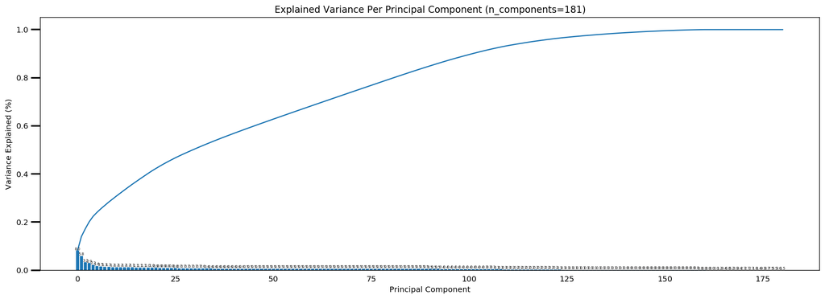

```python
# Apply PCA to the data.
pca = PCA()
general_pca = pca.fit_transform(general_scaled)
scree_plot(pca)
```

By default PCA doesn't reduce many features. The graph of cumulative variance clearly shows a decline in added variance that each features offers.

```
Components: 50
  Explained variance: 0.6166887192335945
Components: 75
  Explained variance: 0.7589044242019138
Components: 100
  Explained variance: 0.8909339272708772
Components: 125
  Explained variance: 0.9663200897697698
Components: 150
  Explained variance: 0.9946352590910286
```

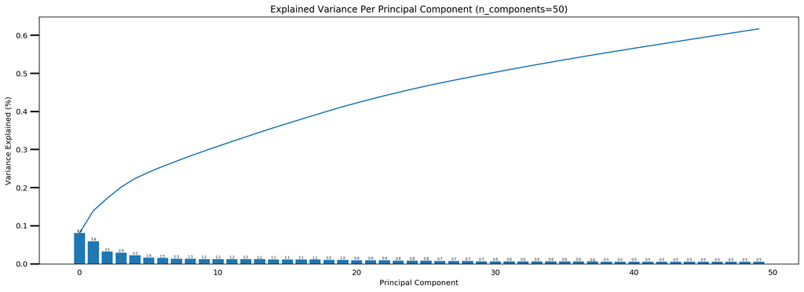

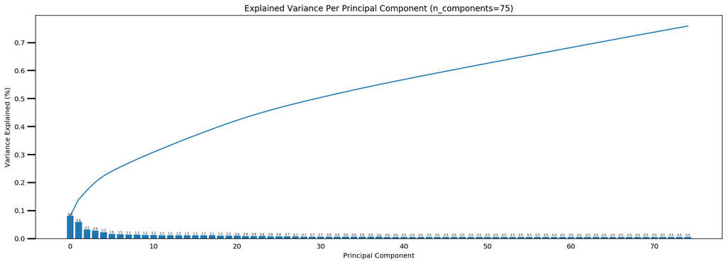

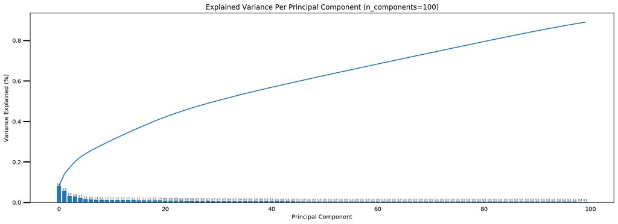

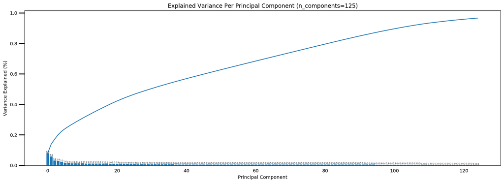

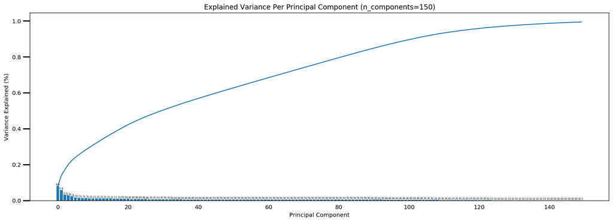

```python
# Re-apply PCA to the data while selecting for number of components to retain.

for components in range(50, 151, 25):
    print(f"Components: {components}")
    pca = PCA(components)
    general_pca = pca.fit_transform(general_scaled)
    print(f"  Explained variance: {pca.explained_variance_ratio_.sum()}")
    scree_plot(pca)
```

```
Components: 92.. Explained variance: 0.8543043583850859
```

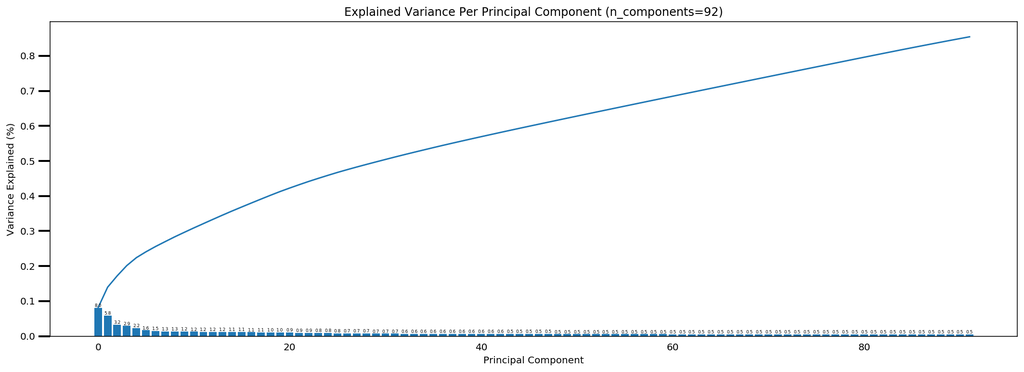

```python
pca = PCA(0.85)
general_pca = pca.fit_transform(general_scaled)
scree_plot(pca)
print(f"Components: {pca.explained_variance_ratio_.size}.. Explained variance: {pca.explained_variance_ratio_.sum()}")
```

### Discussion 2.2: Perform Dimensionality Reduction

In a 2nd step, PCA is applied with a gradual increasing number of components. Initially the total explained variance increases a lot. Eventually around 105 components about 91.25% of the information is still retained.

An alternative option is providing the amount of information that should be retained and let the PCA implementation in sklearn figure out how many components are needed. If 85% of the information suffices, then 92 components will do.

### Step 2.3: Interpret Principal Components

Now that we have our transformed principal components, it's a nice idea to check out the weight of each variable on the first few components to see if they can be interpreted in some fashion.

As a reminder, each principal component is a unit vector that points in the direction of highest variance (after accounting for the variance captured by earlier principal components). The further a weight is from zero, the more the principal component is in the direction of the corresponding feature. If two features have large weights of the same sign (both positive or both negative), then increases in one tend expect to be associated with increases in the other. To contrast, features with different signs can be expected to show a negative correlation: increases in one variable should result in a decrease in the other.

- To investigate the features, you should map each weight to their corresponding feature name, then sort the features according to weight. The most interesting features for each principal component, then, will be those at the beginning and end of the sorted list. Use the data dictionary document to help you understand these most prominent features, their relationships, and what a positive or negative value on the principal component might indicate.
- You should investigate and interpret feature associations from the first three principal components in this substep. To help facilitate this, you should write a function that you can call at any time to print the sorted list of feature weights, for the *i*-th principal component. This might come in handy in the next step of the project, when you interpret the tendencies of the discovered clusters.

```python
def plot_principal_component(data, pca, component):
    components = pd.DataFrame(pca.components_, columns=data.keys()).iloc[component-1]
    components.sort_values(ascending=False, inplace=True)
    components = pd.concat([components.head(5), components.tail(5)])
    print(components)

    components.plot(kind='bar', title='Component ' + str(component))
    ax = plt.gca()
    ax.grid(alpha=0.25)
    ax.set_axisbelow(True)
    plt.show()
```

```
PLZ8_ANTG3                0.192798
CAMEO_INTL_2015_wealth    0.190183
PLZ8_ANTG4                0.186955
HH_EINKOMMEN_SCORE        0.185522
PLZ8_BAUMAX               0.183044
KBA05_GBZ                -0.185869
FINANZ_MINIMALIST        -0.187201
PLZ8_ANTG1               -0.193520
KBA05_ANTG1              -0.195795
MOBI_REGIO               -0.209551
Name: 0, dtype: float64
```

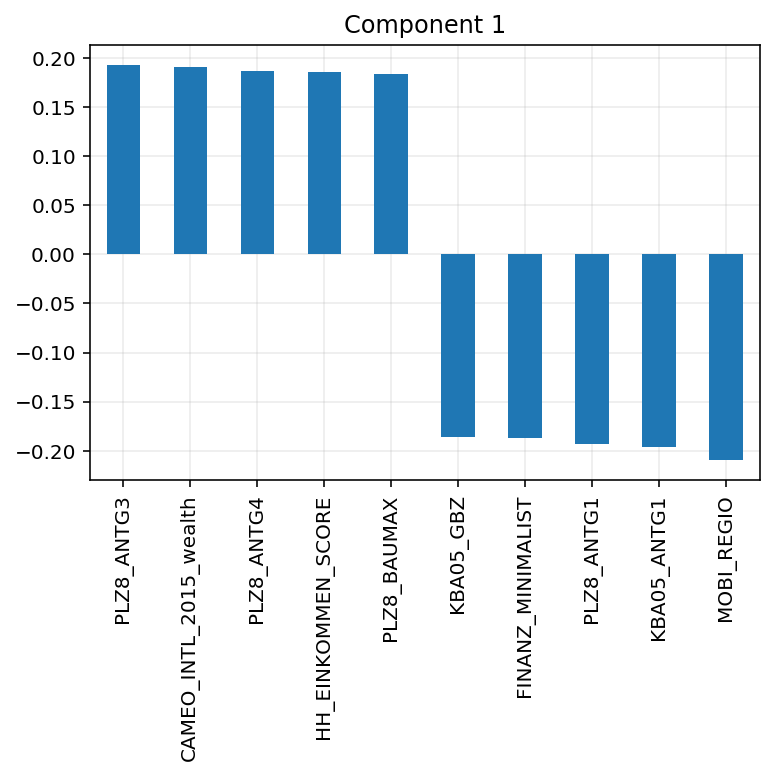

```python
# Map weights for the first principal component to corresponding feature names
# and then print the linked values, sorted by weight.
# HINT: Try defining a function here or in a new cell that you can reuse in the
# other cells.
plot_principal_component(general_clean, pca, 1)
```

```
ALTERSKATEGORIE_GROB                0.240861
FINANZ_VORSORGER                    0.228547
ZABEOTYP_3                          0.203255
SEMIO_ERL                           0.182228
SEMIO_LUST                          0.171278
SEMIO_TRADV                        -0.215545
SEMIO_REL                          -0.218447
FINANZ_UNAUFFAELLIGER              -0.219557
FINANZ_SPARER                      -0.234304
PRAEGENDE_JUGENDJAHRE_generation   -0.246240
Name: 1, dtype: float64
```

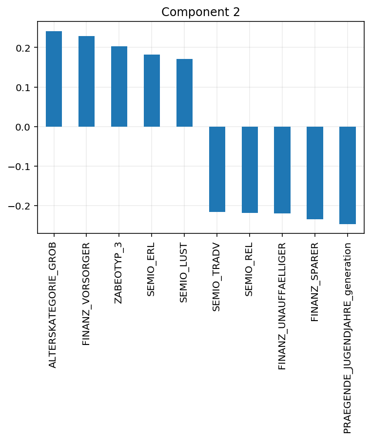

```python
# Map weights for the second principal component to corresponding feature names
# and then print the linked values, sorted by weight.
plot_principal_component(general_clean, pca, 2)
```

```
SEMIO_VERT          0.293306
SEMIO_SOZ           0.242921
SEMIO_FAM           0.235475
SEMIO_KULT          0.224451
GREEN_AVANTGARDE    0.192938
FINANZ_ANLEGER     -0.171551
SEMIO_ERL          -0.196225
SEMIO_DOM          -0.232749
SEMIO_KRIT         -0.250244
SEMIO_KAEM         -0.267527
Name: 2, dtype: float64
```

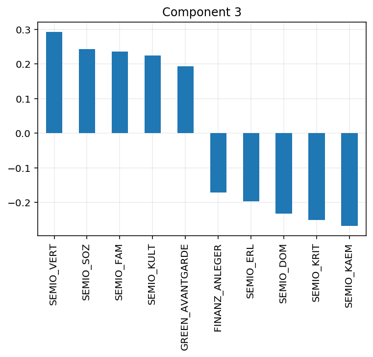

```python
# Map weights for the third principal component to corresponding feature names
# and then print the linked values, sorted by weight.
plot_principal_component(general_clean, pca, 3)
```

### Discussion 2.3: Interpret Principal Components

The **first principal component** is linked positively to following features:

- PLZ8_ANTG3: Number of 6-10 family houses in the PLZ8 region
- CAMEO_INTL_2015_wealth: Wealth Typology
- PLZ8_ANTG4: Number of 10+ family houses in the PLZ8 region

... and negatively with following features:

- PLZ8_ANTG1: Number of 1-2 family houses in the PLZ8 region
- KBA05_ANTG1: Number of 1-2 family houses in the microcell
- MOBI_REGIO: Movement patterns

This PC is mainly linked to family size, in which larger families have a positive impact.

The **second principal component** is linked positively to following features:

- ALTERSKATEGORIE_GROB: Estimated age based on given name analysis
- FINANZ_VORSORGER: Financial typology (be prepared)
- ZABEOTYP_3: Energy consumption typology (fair supplied)

... and negatively with following features:

- FINANZ_UNAUFFAELLIGER: Financial typology (inconspicuous)
- FINANZ_SPARER: Financial typology (money-saver)
- PRAEGENDE_JUGENDJAHRE_generation: Youth decade

This PC is linked to the estimated age, financial and energy consumption typology. Even though these don't seem linked or have something in common, PCA did find a pattern to create a PC based on these features.

- SEMIO_VERT: Personality typology (dreamful)
- SEMIO_SOZ: Personality typology (socially-minded)
- SEMIO_FAM: Personality typology (family-minded)

... and negatively with following features:

- SEMIO_DOM: Personality typology (dominant-minded)
- SEMIO_KRIT: Personality typology (critical-minded)
- SEMIO_KAEM: Personality typology (combative attitude)

The final PC is linked to personality typology. More specific, it associates positively with dreamful, socially-minded and family-minded people.

## Step 3: Clustering

### Step 3.1: Apply Clustering to General Population

You've assessed and cleaned the demographics data, then scaled and transformed them. Now, it's time to see how the data clusters in the principal components space. In this substep, you will apply k-means clustering to the dataset and use the average within-cluster distances from each point to their assigned cluster's centroid to decide on a number of clusters to keep.

- Use sklearn's KMeans class to perform k-means clustering on the PCA-transformed data.
- Then, compute the average difference from each point to its assigned cluster's center. **Hint**: The KMeans object's `.score()` method might be useful here, but note that in sklearn, scores tend to be defined so that larger is better. Try applying it to a small, toy dataset, or use an internet search to help your understanding.
- Perform the above two steps for a number of different cluster counts. You can then see how the average distance decreases with an increasing number of clusters. However, each additional cluster provides a smaller net benefit. Use this fact to select a final number of clusters in which to group the data. **Warning**: because of the large size of the dataset, it can take a long time for the algorithm to resolve. The more clusters to fit, the longer the algorithm will take. You should test for cluster counts through at least 10 clusters to get the full picture, but you shouldn't need to test for a number of clusters above about 30.
- Once you've selected a final number of clusters to use, re-fit a KMeans instance to perform the clustering operation. Make sure that you also obtain the cluster assignments for the general demographics data, since you'll be using them in the final Step 3.3.

```
2 clusters...
  Score: 114520183.15457451
6 clusters...
  Score: 103821704.97316699
10 clusters...
  Score: 99358679.2649073
14 clusters...
  Score: 96609770.47710001
18 clusters...
  Score: 94198311.34682022
22 clusters...
  Score: 91402219.31473167
26 clusters...
  Score: 88917009.10608345
Running: 1765 sec.
```

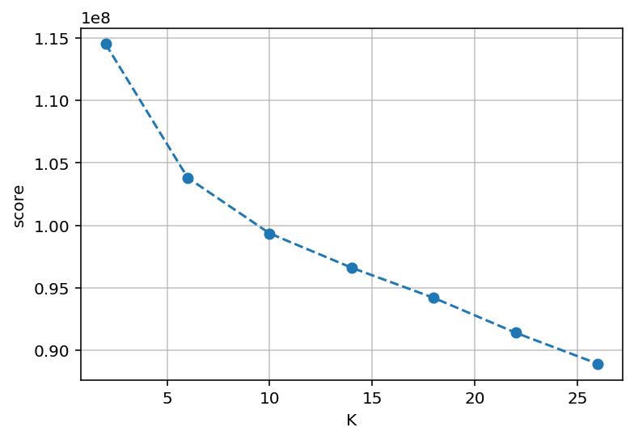

```python
# Over a number of different cluster counts...
    # run k-means clustering on the data and...
    # compute the average within-cluster distances.

start_time = time.time()

scores = []
k_range = range(2, 30, 4)
for k in k_range:
    print(f"{k} clusters...")
    kmeans = KMeans(k).fit(general_pca)
    score = np.abs(kmeans.score(general_pca))
    print(f"  Score: {score}")
    scores.append(score)

plt.plot(k_range, scores, marker='o', linestyle='dashed')
plt.xlabel('K')
plt.ylabel('score')
plt.grid(alpha=0.75)
print(f"Running: {int(time.time() - start_time)} sec.")
```

```python
# Re-fit the k-means model with the selected number of clusters and obtain
# cluster predictions for the general population demographics data.
n_clusters = 14
kmeans = KMeans(n_clusters).fit(general_pca)
general_pred = kmeans.predict(general_pca)
```

### Discussion 3.1: Apply Clustering to General Population

Initially the k-means clustering was performed on a random sample of 25% of the dataset to get the code working. Once this was fine, the clustering was ran against the entire dataset. In order to determine a good value of the number of clusters, the clustering was performed using different values of k (ranging from 2 till 30). The score of the clustering for each value of k was plotted in order to determine the elbow.

Unlike in the course notes, there is no clear elbow here. As of 6 clusters the decrease of score reduces already. So that could be a candidate. However for a dataset of this size, 6 cluster appear few in order to capture the patterns and relationships in the dataset. So instead, I chose to continue with 14 clusters simply because it's halfway down the slope.

### Step 3.2: Apply All Steps to the Customer Data

Now that you have clusters and cluster centers for the general population, it's time to see how the customer data maps on to those clusters. Take care to not confuse this for re-fitting all of the models to the customer data. Instead, you're going to use the fits from the general population to clean, transform, and cluster the customer data. In the last step of the project, you will interpret how the general population fits apply to the customer data.

- Don't forget when loading in the customers data, that it is semicolon (`;`) delimited.
- Apply the same feature wrangling, selection, and engineering steps to the customer demographics using the `clean_data()` function you created earlier. (You can assume that the customer demographics data has similar meaning behind missing data patterns as the general demographics data.)
- Use the sklearn objects from the general demographics data, and apply their transformations to the customers data. That is, you should not be using a `.fit()` or `.fit_transform()` method to re-fit the old objects, nor should you be creating new sklearn objects! Carry the data through the feature scaling, PCA, and clustering steps, obtaining cluster assignments for all of the data in the customer demographics data.

```python
# Load in the customer demographics data.
customers = pd.read_csv('./data/Udacity_CUSTOMERS_Subset.csv', sep=';')
customers.shape
```

```
(191652, 85)
```

```python
# Apply preprocessing, feature transformation, and clustering from the general
# demographics onto the customer data, obtaining cluster predictions for the
# customer demographics data.
customers_clean, customers_many_missing = clean_data(customers)
```

```
Converting missing/unknown values into NaN...
Dropping outlier columns...
Dropping rows many missing features...
  Rows dropping: 49939
Re-encode binary features...
  Column GREEN_AVANTGARDE: [1 0] -> [0 1]
  Column SOHO_KZ: [0. 1.] -> [0. 1.]
  Column OST_WEST_KZ: ['W' 'O'] -> [0 1]
Re-encode multi-level features...
Re-encode mixed-values features...
```

```python
# comparing columns cleaned data
print(f"General: {general_clean.columns.values.size}.. customers: {customers_clean.columns.values.size}")
for c in customers_clean.columns.values:
    if c not in general_clean.columns.values:
        print(f"Missing from general: {c}")
for c in general_clean.columns.values:
    if c not in customers_clean.columns.values:
        print(f"Missing from customers: {c}")
```

```
General: 181.. customers: 180
Missing from customers: GEBAEUDETYP_5.0
```

```python
# to fix this, we simply add a column with values set to 0.
customers_clean['GEBAEUDETYP_5.0'] = 0
```

```python
customers_imp = imp.transform(customers_clean)
customers_scaled = scaler.transform(customers_imp)
customers_pca = pca.transform(customers_scaled)
customers_pred = kmeans.predict(customers_pca)
```

### Step 3.3: Compare Customer Data to Demographics Data

At this point, you have clustered data based on demographics of the general population of Germany, and seen how the customer data for a mail-order sales company maps onto those demographic clusters. In this final substep, you will compare the two cluster distributions to see where the strongest customer base for the company is.

Consider the proportion of persons in each cluster for the general population, and the proportions for the customers. If we think the company's customer base to be universal, then the cluster assignment proportions should be fairly similar between the two. If there are only particular segments of the population that are interested in the company's products, then we should see a mismatch from one to the other. If there is a higher proportion of persons in a cluster for the customer data compared to the general population (e.g. 5% of persons are assigned to a cluster for the general population, but 15% of the customer data is closest to that cluster's centroid) then that suggests the people in that cluster to be a target audience for the company. On the other hand, the proportion of the data in a cluster being larger in the general population than the customer data (e.g. only 2% of customers closest to a population centroid that captures 6% of the data) suggests that group of persons to be outside of the target demographics.

Take a look at the following points in this step:

- Compute the proportion of data points in each cluster for the general population and the customer data. Visualizations will be useful here: both for the individual dataset proportions, but also to visualize the ratios in cluster representation between groups. Seaborn's [`countplot()`](https://seaborn.pydata.org/generated/seaborn.countplot.html) or [`barplot()`](https://seaborn.pydata.org/generated/seaborn.barplot.html) function could be handy.
  - Recall the analysis you performed in step 1.1.3 of the project, where you separated out certain data points from the dataset if they had more than a specified threshold of missing values. If you found that this group was qualitatively different from the main bulk of the data, you should treat this as an additional data cluster in this analysis. Make sure that you account for the number of data points in this subset, for both the general population and customer datasets, when making your computations!
- Which cluster or clusters are overrepresented in the customer dataset compared to the general population? Select at least one such cluster and infer what kind of people might be represented by that cluster. Use the principal component interpretations from step 2.3 or look at additional components to help you make this inference. Alternatively, you can use the `.inverse_transform()` method of the PCA and StandardScaler objects to transform centroids back to the original data space and interpret the retrieved values directly.
- Perform a similar investigation for the underrepresented clusters. Which cluster or clusters are underrepresented in the customer dataset compared to the general population, and what kinds of people are typified by these clusters?

```python
general_pred.size
```

```
797961
```

```python
customers_pred.size
```

```
141713
```

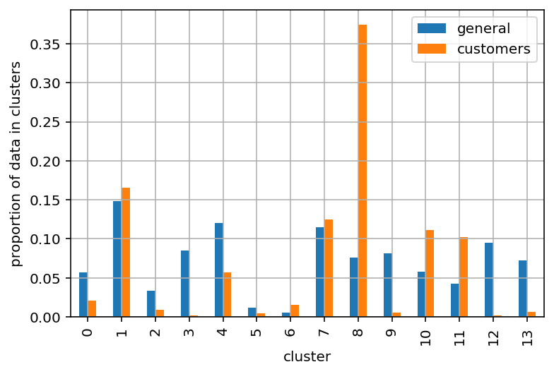

```python
# Compare the proportion of data in each cluster for the customer data to the
# proportion of data in each cluster for the general population.
general_prop = []
customers_prop = []
for ki in range(n_clusters):
    general_prop.append((general_pred == ki).sum()/general_pred.size)
    customers_prop.append((customers_pred == ki).sum()/customers_pred.size)

df_prop = pd.DataFrame({
    'cluster': range(n_clusters),
    'general': general_prop,
    'customers': customers_prop
})

df_prop.plot(x='cluster',y=['general', 'customers'], kind='bar')
plt.ylabel('proportion of data in clusters')
plt.grid(True)
plt.show()
```

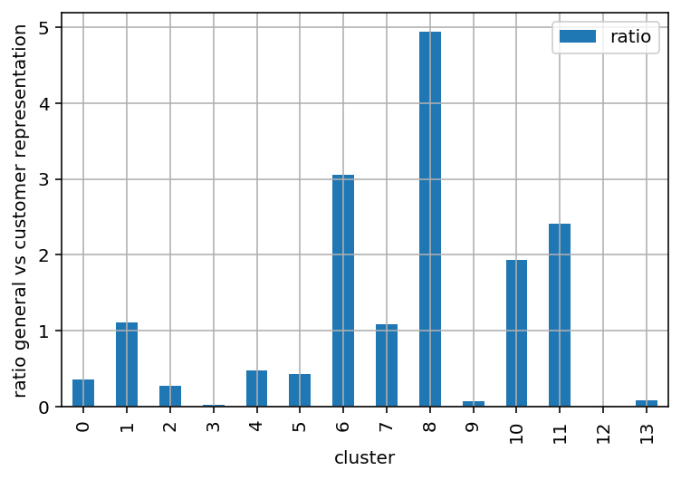

```
8     4.943369
6     3.051240
11    2.410083
10    1.931352
1     1.115330
7     1.085400
4     0.473239
5     0.424534
0     0.357538
2     0.269495
13    0.084618
9     0.065913
3     0.023035
12    0.014418
dtype: float64
```

```python
# Calculate ratios of customers to general population.
customers_general_prop_ratios = df_prop['customers'] / df_prop['general']
df_prop_ratios = pd.DataFrame({
    'cluster': range(n_clusters),
    'ratio': customers_general_prop_ratios
})
df_prop_ratios.plot(x='cluster', y=['ratio'], kind='bar')
plt.ylabel('ratio general vs customer representation')
plt.grid(True)
plt.show()

customers_general_prop_ratios.sort_values(ascending=False, inplace=True)
customers_general_prop_ratios
```

```python
# Store the top 10 most important features for each PC.
relevant_features = []
df = pd.DataFrame(pca.components_, columns=azdias.keys())
for c in range(pca.components_.shape[0]):
    relevant_features.append(df.iloc[c].sort_values(ascending=False).head(10).index.values)
```

```python
cluster_centers = scaler.inverse_transform(pca.inverse_transform(kmeans.cluster_centers_))
cluster_centers_df = pd.DataFrame(cluster_centers, columns=customers_clean.columns)
```

```python
# What kinds of people are part of a cluster that is overrepresented in the
# customer data compared to the general population?
print("Overrepresented:")
print(customers_general_prop_ratios[:5])
```

```
Overrepresented:
8     4.943369
6     3.051240
11    2.410083
10    1.931352
1     1.115330
dtype: float64
```

```python
# Clusters 8, 6 and 11.
for c in [8, 6, 11]:
    print(f"Cluster {c}...")
    print(cluster_centers_df[relevant_features[c]].loc[c].round(0))
    print("---")
```

```
Cluster 8...
CAMEO_INTL_2015_lifestage    2.0
OST_WEST_KZ                  0.0
CAMEO_DEUG_2015_3            0.0
CAMEO_DEU_2015_3D            0.0
ARBEIT                       3.0
LP_STATUS_GROB_3.0          -0.0
CAMEO_DEU_2015_6E            0.0
CAMEO_DEUG_2015_6            0.0
FINANZTYP_6                  0.0
CAMEO_DEU_2015_8D            0.0
Name: 8, dtype: float64
---
Cluster 6...
LP_STATUS_GROB_3.0     0.0
GEBAEUDETYP_3.0        0.0
LP_STATUS_FEIN_6.0     0.0
LP_STATUS_FEIN_7.0     0.0
ANZ_HH_TITEL          -0.0
CAMEO_DEUG_2015_5     -0.0
ANZ_TITEL              0.0
ANZ_HAUSHALTE_AKTIV    3.0
KBA05_ANTG4            0.0
CAMEO_DEU_2015_5D     -0.0
Name: 6, dtype: float64
---
Cluster 11...
CAMEO_DEUG_2015_8      0.0
CAMEO_DEU_2015_8A      0.0
KBA13_ANZAHL_PKW     653.0
PLZ8_HHZ               4.0
CAMEO_DEUG_2015_3      0.0
CAMEO_DEU_2015_8C      0.0
CAMEO_DEU_2015_8B      0.0
PLZ8_GBZ               4.0
CAMEO_DEU_2015_8D      0.0
CAMEO_DEU_2015_3C      0.0
Name: 11, dtype: float64
---
```

```python
# Describe numerical features for cluster 8.
general_clean[['CAMEO_INTL_2015_lifestage', 'ARBEIT']].describe()
```

|  | CAMEO_INTL_2015_lifestage | ARBEIT |
| --- | --- | --- |
| count | 791840.000000 | 793734.000000 |
| mean | 2.873022 | 3.166730 |
| std | 1.484775 | 0.999059 |
| min | 1.000000 | 1.000000 |
| 25% | 1.000000 | 3.000000 |
| 50% | 3.000000 | 3.000000 |
| 75% | 4.000000 | 4.000000 |
| max | 5.000000 | 5.000000 |

```python
# What kinds of people are part of a cluster that is underrepresented in the
# customer data compared to the general population?
print("Underrepresented:")
print(customers_general_prop_ratios[-5:])
```

[output not shown]

```python
# Clusters 12, 3 and 9
for c in [12, 3, 9]:
    print(f"Cluster {c}...")
    print(cluster_centers_df[relevant_features[c]].loc[c].round(0))
    print("---")
```

```
Cluster 12...
CAMEO_DEUG_2015_4      0.0
CAMEO_DEUG_2015_6      0.0
LP_STATUS_GROB_3.0     0.0
LP_STATUS_FEIN_6.0     0.0
CAMEO_DEU_2015_6B      0.0
CAMEO_DEU_2015_4C      0.0
CAMEO_DEU_2015_4A      0.0
LP_FAMILIE_GROB_4.0    0.0
LP_FAMILIE_GROB_2.0    0.0
LP_FAMILIE_FEIN_2.0    0.0
Name: 12, dtype: float64
---
Cluster 3...
SEMIO_KAEM                         4.0
SEMIO_DOM                          5.0
PRAEGENDE_JUGENDJAHRE_movement     4.0
GREEN_AVANTGARDE                   0.0
LP_STATUS_GROB_5.0                 0.0
LP_STATUS_FEIN_10.0                0.0
LP_LEBENSPHASE_GROB                3.0
ORTSGR_KLS9                        7.0
LP_LEBENSPHASE_FEIN               10.0
EWDICHTE                           5.0
Name: 3, dtype: float64
---
Cluster 9...
LP_STATUS_GROB_3.0     0.0
LP_STATUS_FEIN_6.0     0.0
LP_STATUS_GROB_4.0     0.0
LP_STATUS_FEIN_9.0     0.0
KBA05_ANTG2            1.0
LP_STATUS_FEIN_7.0     0.0
LP_FAMILIE_GROB_2.0    0.0
LP_FAMILIE_FEIN_2.0    0.0
CAMEO_DEUG_2015_6      0.0
W_KEIT_KIND_HH         4.0
Name: 9, dtype: float64
---
```

### Discussion 3.3: Compare Customer Data to Demographics Data

**Overrepresented**

Overrepresented means that the customer dataset contains a higher proportion of people corresponding with this cluster compared to the general demographic dataset. In other words, as company you have more customers belonging to this cluster. This could be because your services or products appeal more to people from this cluster. This also means that the company could specifically target its advertisements towards this group of people in order to attract more customers.

People in cluster 8 match with following features:

[output not shown]

**Underrepresented**

Underrepresented is the inverse. The customer dataset contains a lower proportion of people from this cluster compared to the general demographic dataset. As company you have less customers from this cluster and as such you shouldn't target this cluster with advertisement.

People in cluster 9

| Feature | Values | Meaning |
| --- | --- | --- |
| LP_STATUS_GROB | Not 3 (= independents), Not 4 (= houseowners) | Social status, rough scale |
| LP_STATUS_FEIN | Not 6 (=independent workers), Not 7 (= title holder-households), Not 9 (= houseowners) | Social status, fine scale |
| KBA05_ANTG2 | 1 (= lower share) | Number of 3-5 family houses in the microcell |
| LP_FAMILIE_GROB | Not 2 (= couple) | Family type, rough scale |
| LP_FAMILIE_FEIN | Not 2 (= couple) | Family type, fine scale |
| CAMEO_DEUG_2015 | Not 6 (= low-consumption middleclass) | Wealth / Life Stage Typology, rough scale |
| W_KEIT_KIND_HH | 4 (average) | Likelihood of children in household |

The person represented by cluster 9 is not an independent or houseowner. He or she lives in a microcell with a lower number of family houses and is not partner of a couples relationship. There is an average likelyhood of children in his/her household. This persion is also not a member of the low-consumption middleclass. Based on the data dictionary and the previous characteristics, this underrepresented group of people could be high-performers/high-achievers that have top-executive positions in enterprise and are focused on their career.

> Congratulations on making it this far in the project! Before you finish, make sure to check through the entire notebook from top to bottom to make sure that your analysis follows a logical flow and all of your findings are documented in **Discussion** cells. Once you've checked over all of your work, you should export the notebook as an HTML document to submit for evaluation. You can do this from the menu, navigating to **File -> Download as -> HTML (.html)**. You will submit both that document and this notebook for your project submission.